# Modelagem Econométrica de Conjoint e Otimização Prescritiva de Portfólio

> **Notas Metodológicas & Desenho Experimental (D-Optimal):**
> - **Amostragem & Painel:** Coleta primária online com **N = 420** respondentes recrutados. Após filtros estritos de qualidade de dados (*speeders*, *straightliners* e checagens de consistência interna), obteve-se uma amostra final válida de **N = 377 respondentes** (taxa de retenção de **89,8%**), totalizando **7.540 tarefas de escolha discreta** (**30.160** alternativas avaliadas).
> - **Desenho D-Optimal:** A partir do espaço fatorial completo (108 combinações de atributos vs. vetor de preços contínuo), aplicou-se um algoritmo de **Desenho Fatorial Fracionário D-Optimal** (D-Efficiency > 95%), maximizando a ortogonalidade entre atributos e balanceamento de níveis (*level balance*) com sobreposição mínima (*minimal overlap*).
> - **Estrutura das Tarefas (CBC):** Cada respondente avaliou **20 tarefas de escolha** com **3 conceitos de produto + 1 opção explícita de Não-Compra (Opt-Out)**, permitindo identificar elasticidade de mercado e fuga de categoria.

### Visão Geral do Pipeline Analítico:

1. **Carga e Inspeção dos Dados Coletados:** Visualização da estrutura da base do painel.
2. **Análise Exploratória (EDA):** Frequência de escolhas por atributo e taxa global de Opt-Out.
3. **Logit Condicional (MNL) Populacional:** Estimação dos parâmetros médios e importância relativa.
4. **Diagnóstico de Heterogeneidade:** Teste de Bimodalidade de Ashman (D) para comprovação empírica de segmentos latentes.
5. **Classes Latentes (LC-MNL via EM):** Segmentação de mercado baseada em utilidade e cálculo de Disposição a Pagar (WTP em USD).
6. **Matriz Estratégica de Portfólio (108 Combos):** Simulação simultânea de market share x lucro unitário por segmento.
7. **Diagnóstico da Prateleira Atual da Loja:** Identificação de ineficiências e distorções no cardápio (portifolio preotm.csv).
8. **Cálculo de Preço Ótimo por Demanda Agregada Multivariada (Solver L-BFGS-B):** Maximização de lucro da prateleira integrando elasticidade cruzada, canibalização e opt-out.
9. **Otimização Combinatória de Assortment:** Curva de tradeoff para redução da complexidade de SKUs.

## 1. Carga e Inspeção dos Dados Coletados

Importação direta da base de dados padronizada resultante da coleta.

```python
import pandas as pd
import numpy as np
import matplotlib.pyplot as plt
import seaborn as sns
import statsmodels.api as sm
from statsmodels.discrete.conditional_models import ConditionalLogit
import warnings
import itertools

# Carregamento da base limpa da pesquisa de escolhas
df_survey = pd.read_csv('cbc_survey_limpo.csv')

print(f"Dimensão da base de dados: {df_survey.shape[0]:,} linhas x {df_survey.shape[1]} colunas")
print(f"Total de tarefas de escolha registradas: {df_survey['unique_task_id'].nunique():,}")
print(f"Total de respondentes: {df_survey['respondent_id'].nunique():,}")

display(df_survey.head(6))
```

```
Dimensão da base de dados: 30,160 linhas x 12 colunas
Total de tarefas de escolha registradas: 7,540
Total de respondentes: 377
```

|  | Hamburguer | Refrigerante | Batata | Sobremesa | Nuggets | price | price_k | respondent_id | task_id | unique_task_id | choice | is_none |
| --- | --- | --- | --- | --- | --- | --- | --- | --- | --- | --- | --- | --- |
| 0 | Simples 50g | Refri Grande (G) | Batata Pequena (P) | Milkshake Gourmet | Sem Nuggets | 7040.0 | 7.0400 | 1 | 1 | 1 | 0 | 0 |
| 1 | Duplo 100g | Refri Médio (M) | Batata Pequena (P) | Milkshake Gourmet | Sem Nuggets | 6742.5 | 6.7425 | 1 | 1 | 1 | 0 | 0 |
| 2 | Duplo 100g | Refri Médio (M) | Batata Média (M) | Sem Sobremesa | Porção de Nuggets | 2495.5 | 2.4955 | 1 | 1 | 1 | 1 | 0 |
| 3 | Nenhum | Nenhum | Nenhum | Nenhum | Sem Nuggets | 0.0 | 0.0000 | 1 | 1 | 1 | 0 | 1 |
| 4 | Simples 50g | Refri Pequeno (P) | Batata Pequena (P) | Sem Sobremesa | Sem Nuggets | 2000.0 | 2.0000 | 1 | 2 | 2 | 0 | 0 |
| 5 | Duplo 100g | Refri Pequeno (P) | Batata Pequena (P) | Milkshake Gourmet | Porção de Nuggets | 6071.0 | 6.0710 | 1 | 2 | 2 | 0 | 0 |

## 2. Análise Exploratória (Frequência de Escolhas e Opt-Out)

Inspeção da distribuição de escolhas observadas para cada nível de atributo e proporção de desistência de compra (*Opt-Out*).

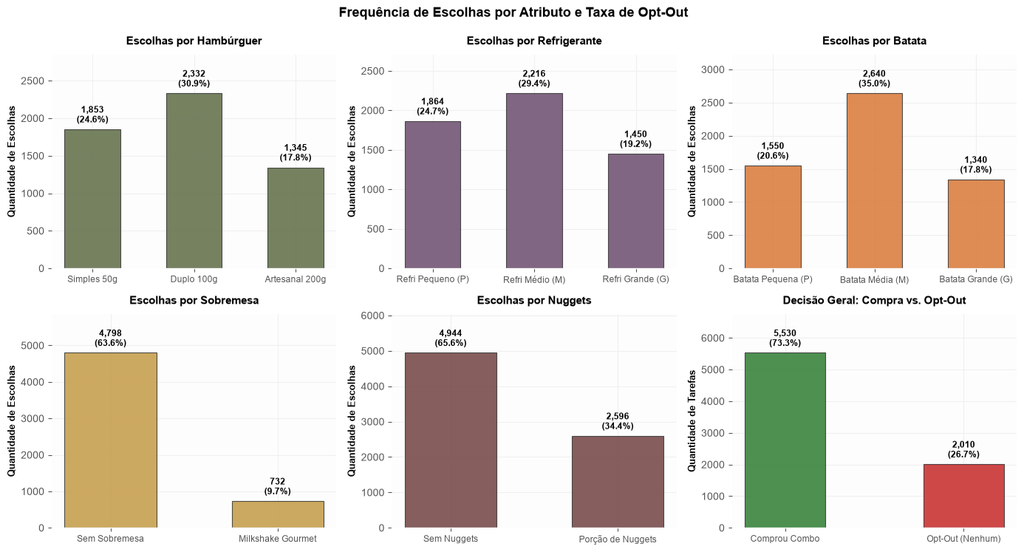

```python
attribute_levels_ordered = {
    'Hamburguer': ('Escolhas por Hambúrguer', ['Simples 50g', 'Duplo 100g', 'Artesanal 200g']),
    'Refrigerante': ('Escolhas por Refrigerante', ['Refri Pequeno (P)', 'Refri Médio (M)', 'Refri Grande (G)']),
    'Batata': ('Escolhas por Batata', ['Batata Pequena (P)', 'Batata Média (M)', 'Batata Grande (G)']),
    'Sobremesa': ('Escolhas por Sobremesa', ['Sem Sobremesa', 'Milkshake Gourmet']),
    'Nuggets': ('Escolhas por Nuggets', ['Sem Nuggets', 'Porção de Nuggets'])
}

colors_palette = ['#5e6b45', '#6a4c6d', '#d97736', '#c49a45', '#704241']

plt.style.use('ggplot')
plt.rcParams.update({
    'font.family': 'sans-serif',
    'font.sans-serif': ['Arial', 'DejaVu Sans'],
    'axes.facecolor': '#fdfdfd',
    'figure.facecolor': 'white',
    'grid.color': '#f0f0f0'
})

fig, axes = plt.subplots(2, 3, figsize=(14, 7.5))
axes = axes.flatten()

df_chosen = df_survey[df_survey['choice'] == 1]
total_tasks = len(df_chosen)

# Frequência observada para os 5 atributos
for idx, (col_attr, (title_attr, ordered_levels)) in enumerate(attribute_levels_ordered.items()):
    ax = axes[idx]
    color = colors_palette[idx % len(colors_palette)]

    counts_series = df_chosen[col_attr].value_counts()
    categories = [lvl for lvl in ordered_levels if lvl in counts_series.index]
    values = [counts_series[lvl] for lvl in categories]

    bars = ax.bar(categories, values, color=color, alpha=0.85, edgecolor='#333333', linewidth=0.8, width=0.55)
    ax.set_title(title_attr, fontsize=11, weight='bold', pad=10, color='black')
    ax.set_ylabel("Quantidade de Escolhas", fontsize=9, weight='bold', color='black')
    ax.set_ylim(0, max(values) * 1.22)

    for bar, val in zip(bars, values):
        pct = (val / total_tasks) * 100
        ax.text(
            bar.get_x() + bar.get_width() / 2.0,
            bar.get_height() + (max(values) * 0.025),
            f"{val:,}\n({pct:.1f}%)",
            ha='center', va='bottom', fontsize=8.5, weight='bold', color='black'
        )

    ax.tick_params(axis='x', labelsize=8.5)
    for spine in ['top', 'right', 'left']:
        ax.spines[spine].set_visible(False)

# Painel 6: Decisão de Compra vs Opt-Out
ax6 = axes[5]
none_count = len(df_chosen[df_chosen['is_none'] == 1])
bought_count = total_tasks - none_count

optout_categories = ['Comprou Combo', 'Opt-Out (Nenhum)']
optout_values = [bought_count, none_count]
optout_colors = ['#2e7d32', '#c62828']

bars6 = ax6.bar(optout_categories, optout_values, color=optout_colors, alpha=0.85, edgecolor='#333333', linewidth=0.8, width=0.45)
ax6.set_title("Decisão Geral: Compra vs. Opt-Out", fontsize=11, weight='bold', pad=10, color='black')
ax6.set_ylabel("Quantidade de Tarefas", fontsize=9, weight='bold', color='black')
ax6.set_ylim(0, max(optout_values) * 1.22)

for bar, val in zip(bars6, optout_values):
    pct = (val / total_tasks) * 100
    ax6.text(
        bar.get_x() + bar.get_width() / 2.0,
        bar.get_height() + (max(optout_values) * 0.025),
        f"{val:,}\n({pct:.1f}%)",
        ha='center', va='bottom', fontsize=8.5, weight='bold', color='black'
    )

ax6.tick_params(axis='x', labelsize=8.5)
for spine in ['top', 'right', 'left']:
    ax6.spines[spine].set_visible(False)

plt.suptitle("Frequência de Escolhas por Atributo e Taxa de Opt-Out", fontsize=13, weight='bold', y=0.99, color='black')
plt.tight_layout()
plt.show()
```

## 3. Modelo Logit Condicional (MNL) Populacional

Estimação dos coeficientes de utilidade média populacional via Logit Condicional de McFadden com grupos definidos por `unique_task_id`.

```python
# Criação das variáveis dummy para as alternativas
df_all_dummies = pd.get_dummies(
    df_survey,
    columns=['Hamburguer', 'Refrigerante', 'Batata', 'Sobremesa', 'Nuggets'],
    dtype=float
)

clean_cols = {col: col.replace(' ', '_').replace('(', '').replace(')', '') for col in df_all_dummies.columns}
df_all_dummies = df_all_dummies.rename(columns=clean_cols)

# Seleciona dummies estimáveis (omitindo categorias base e opção Nenhum)
feature_cols = [c for c in df_all_dummies.columns if (
    ('Hamburguer_' in c and 'Simples' not in c and 'Nenhum' not in c) or
    ('Refrigerante_' in c and 'Pequeno' not in c and 'Nenhum' not in c) or
    ('Batata_' in c and 'Pequena' not in c and 'Nenhum' not in c) or
    ('Sobremesa_' in c and 'Sem_Sobremesa' not in c and 'Nenhum' not in c) or
    ('Nuggets_' in c and 'Sem_Nuggets' not in c and 'Nenhum' not in c)
)] + ['price_k', 'is_none']

# Ajuste do Logit Condicional Agregado
clogit_model = ConditionalLogit(
    endog=df_all_dummies['choice'],
    exog=df_all_dummies[feature_cols],
    groups=df_all_dummies['unique_task_id']
)
results = clogit_model.fit(disp=False)

results_df = pd.DataFrame({
    'Beta': results.params,
    'Erro Padrao': results.bse,
    'z-stat': results.tvalues,
    'p-valor': [f"{p:.4e}" for p in results.pvalues],
    'Odds Ratio (e^Beta)': np.exp(results.params)
})

print("=== Regressão Logit Condicional (Modelo Populacional Médio) ===")
display(results_df)

params = results.params.to_dict()

# Tabela consolidada com níveis base fixados em 0.0
all_levels_utility = [
    {'Atributo': 'Hambúrguer', 'Nível': 'Simples 50g (Base)', 'Utilidade': 0.0000, 'Tipo': 'Referência'},
    {'Atributo': 'Hambúrguer', 'Nível': 'Duplo 100g', 'Utilidade': params.get('Hamburguer_Duplo_100g', 0.0), 'Tipo': 'Estimado'},
    {'Atributo': 'Hambúrguer', 'Nível': 'Artesanal 200g', 'Utilidade': params.get('Hamburguer_Artesanal_200g', 0.0), 'Tipo': 'Estimado'},

    {'Atributo': 'Refrigerante', 'Nível': 'Refri Pequeno (P) (Base)', 'Utilidade': 0.0000, 'Tipo': 'Referência'},
    {'Atributo': 'Refrigerante', 'Nível': 'Refri Médio (M)', 'Utilidade': params.get('Refrigerante_Refri_Médio_M', 0.0), 'Tipo': 'Estimado'},
    {'Atributo': 'Refrigerante', 'Nível': 'Refri Grande (G)', 'Utilidade': params.get('Refrigerante_Refri_Grande_G', 0.0), 'Tipo': 'Estimado'},

    {'Atributo': 'Batata', 'Nível': 'Batata Pequena (P) (Base)', 'Utilidade': 0.0000, 'Tipo': 'Referência'},
    {'Atributo': 'Batata', 'Nível': 'Batata Média (M)', 'Utilidade': params.get('Batata_Batata_Média_M', 0.0), 'Tipo': 'Estimado'},
    {'Atributo': 'Batata', 'Nível': 'Batata Grande (G)', 'Utilidade': params.get('Batata_Batata_Grande_G', 0.0), 'Tipo': 'Estimado'},

    {'Atributo': 'Sobremesa', 'Nível': 'Sem Sobremesa (Base)', 'Utilidade': 0.0000, 'Tipo': 'Referência'},
    {'Atributo': 'Sobremesa', 'Nível': 'Milkshake Gourmet', 'Utilidade': params.get('Sobremesa_Milkshake_Gourmet', 0.0), 'Tipo': 'Estimado'},

    {'Atributo': 'Nuggets', 'Nível': 'Sem Nuggets (Base)', 'Utilidade': 0.0000, 'Tipo': 'Referência'},
    {'Atributo': 'Nuggets', 'Nível': 'Porção de Nuggets', 'Utilidade': params.get('Nuggets_Porção_de_Nuggets', 0.0), 'Tipo': 'Estimado'},

    {'Atributo': 'Preço (Contínuo)', 'Nível': 'Por kUSD (+1.000 USD)', 'Utilidade': params.get('price_k', 0.0), 'Tipo': 'Coeficiente Contínuo'},
    {'Atributo': 'Opt-Out', 'Nível': 'Opção Nenhum', 'Utilidade': params.get('is_none', 0.0), 'Tipo': 'Constante de Não-Compra'}
]

df_all_levels = pd.DataFrame(all_levels_utility)
display(df_all_levels)
```

```
=== Regressão Logit Condicional (Modelo Populacional Médio) ===
```

|  | Beta | Erro Padrao | z-stat | p-valor | Odds Ratio (e^Beta) |
| --- | --- | --- | --- | --- | --- |
| Hamburguer_Artesanal_200g | 1.656893 | 0.090601 | 18.287869 | 1.0338e-74 | 5.242995 |
| Hamburguer_Duplo_100g | 1.345270 | 0.059263 | 22.699948 | 4.4852e-114 | 3.839224 |
| Refrigerante_Refri_Grande_G | 0.849176 | 0.058370 | 14.548260 | 5.9908e-48 | 2.337719 |
| Refrigerante_Refri_Médio_M | 0.477969 | 0.048522 | 9.850580 | 6.8150e-23 | 1.612795 |
| Batata_Batata_Grande_G | 0.799397 | 0.053710 | 14.883496 | 4.2187e-50 | 2.224199 |
| Batata_Batata_Média_M | 0.379860 | 0.045009 | 8.439728 | 3.1808e-17 | 1.462080 |
| Sobremesa_Milkshake_Gourmet | 2.105771 | 0.147846 | 14.243033 | 4.9530e-46 | 8.213431 |
| Nuggets_Porção_de_Nuggets | 0.473674 | 0.037741 | 12.550704 | 3.9399e-36 | 1.605883 |
| price_k | -1.121959 | 0.038695 | -28.995119 | 7.5812e-185 | 0.325641 |
| is_none | -1.977014 | 0.084391 | -23.426821 | 2.2781e-121 | 0.138482 |

|  | Atributo | Nível | Utilidade | Tipo |
| --- | --- | --- | --- | --- |
| 0 | Hambúrguer | Simples 50g (Base) | 0.000000 | Referência |
| 1 | Hambúrguer | Duplo 100g | 1.345270 | Estimado |
| 2 | Hambúrguer | Artesanal 200g | 1.656893 | Estimado |
| 3 | Refrigerante | Refri Pequeno (P) (Base) | 0.000000 | Referência |
| 4 | Refrigerante | Refri Médio (M) | 0.477969 | Estimado |
| 5 | Refrigerante | Refri Grande (G) | 0.849176 | Estimado |
| 6 | Batata | Batata Pequena (P) (Base) | 0.000000 | Referência |
| 7 | Batata | Batata Média (M) | 0.379860 | Estimado |
| 8 | Batata | Batata Grande (G) | 0.799397 | Estimado |
| 9 | Sobremesa | Sem Sobremesa (Base) | 0.000000 | Referência |
| 10 | Sobremesa | Milkshake Gourmet | 2.105771 | Estimado |
| 11 | Nuggets | Sem Nuggets (Base) | 0.000000 | Referência |
| 12 | Nuggets | Porção de Nuggets | 0.473674 | Estimado |
| 13 | Preço (Contínuo) | Por kUSD (+1.000 USD) | -1.121959 | Coeficiente Contínuo |
| 14 | Opt-Out | Opção Nenhum | -1.977014 | Constante de Não-Compra |

Cálculo da importância relativa dos atributos pelo método da amplitude de utilidade (Range Method).

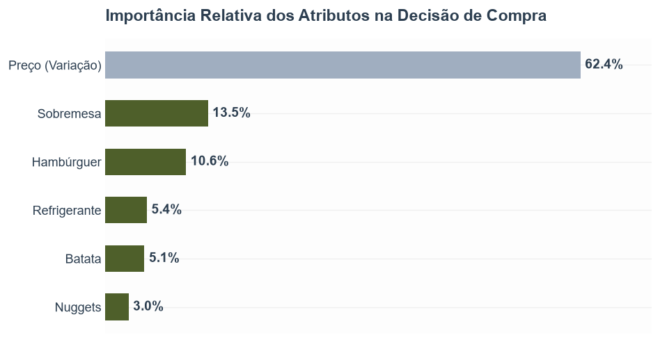

```python
# -------------------------------------------------------------
# 1. Cálculo da Importância Relativa dos Atributos
# -------------------------------------------------------------
def get_attr_range(attr_name):
    sub = df_all_levels[df_all_levels['Atributo'] == attr_name]['Utilidade']
    return sub.max() - sub.min()

ranges = {
    'Hambúrguer': get_attr_range('Hambúrguer'),
    'Refrigerante': get_attr_range('Refrigerante'),
    'Batata': get_attr_range('Batata'),
    'Sobremesa': get_attr_range('Sobremesa'),
    'Nuggets': get_attr_range('Nuggets'),
    'Preço (Variação)': abs(params['price_k'] * (df_survey['price_k'].max() - df_survey['price_k'].min()))
}

total_range = sum(ranges.values())
df_importance = pd.DataFrame([
    {'Atributo': k, 'Importancia_%': (v / total_range) * 100} for k, v in ranges.items()
]).sort_values('Importancia_%', ascending=True)

# -------------------------------------------------------------
# 2. Gráfico Limpo & Elegante
# -------------------------------------------------------------
fig, ax = plt.subplots(figsize=(8, 4.2), dpi=120)

# Cores: Destaque suave nos maiores drivers, neutro elegante nos demais
colors = ['#4E5F2A' if val < 15 else '#A0AEC0' for val in df_importance['Importancia_%']]

bars = ax.barh(
    df_importance['Atributo'],
    df_importance['Importancia_%'],
    color=colors,
    height=0.55,
    edgecolor='none'
)

# Valores no final de cada barra
for bar, val in zip(bars, df_importance['Importancia_%']):
    ax.text(
        val + 0.6,
        bar.get_y() + bar.get_height() / 2,
        f"{val:.1f}%",
        va='center',
        ha='left',
        fontsize=11.5,
        weight='bold',
        color='#2c3e50'
    )

# Tipografia e Layout Limpo
ax.set_title("Importância Relativa dos Atributos na Decisão de Compra", fontsize=13.5, weight='bold', pad=15, color='#2c3e50', loc='left')
ax.set_xlim(0, df_importance['Importancia_%'].max() * 1.15)
ax.xaxis.grid(True, linestyle='--', alpha=0.3, color='#bdc3c7')
ax.set_axisbelow(True)

# Remove molduras desnecessárias
for spine in ['top', 'right', 'bottom', 'left']:
    ax.spines[spine].set_visible(False)
ax.xaxis.set_visible(False)
ax.tick_params(axis='y', length=0, labelsize=11, labelcolor='#2c3e50')

plt.tight_layout()
plt.show()
```

## 4. Diagnóstico de Heterogeneidade e Bimodalidade (Ashman D)

Estimação de coeficientes individuais com contração de ruído (*noise-shrinkage*) e aplicação do **Teste D de Ashman** via Gaussian Mixture Models (GMM com $k=2$) para verificar se a população é bimodal.

|  | Atributo / Nível | Ashman D | Status | Shapiro-Wilk (p) |
| --- | --- | --- | --- | --- |
| 0 | Hambúrguer: Artesanal 200g | 2.16 | BIMODAL (Segmentação Justificada) | 1.563e-05 |
| 1 | Hambúrguer: Duplo 100g | 1.05 | Unimodal | 4.868e-08 |
| 2 | Refrigerante: Refri Grande (G) | 1.88 | BIMODAL (Segmentação Justificada) | 4.532e-05 |
| 3 | Refrigerante: Refri Médio (M) | 0.01 | Unimodal | 5.207e-07 |
| 4 | Batata: Batata Grande (G) | 0.94 | Unimodal | 1.275e-03 |
| 5 | Batata: Batata Média (M) | 1.21 | Unimodal | 3.370e-05 |
| 6 | Sobremesa: Milkshake Gourmet | 2.63 | BIMODAL (Segmentação Justificada) | 1.255e-06 |
| 7 | Nuggets: Porção de Nuggets | 0.02 | Unimodal | 5.220e-08 |
| 8 | Preço (Coeficiente Contínuo) | 2.07 | BIMODAL (Segmentação Justificada) | 9.512e-17 |
| 9 | Opt-Out (Opção Nenhum) | 1.25 | Unimodal | 2.970e-05 |

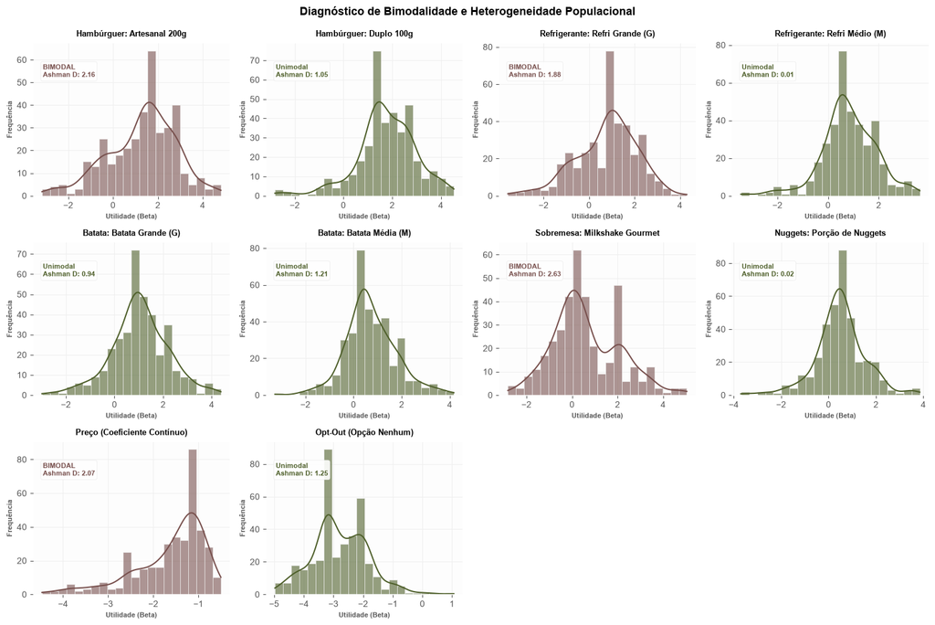

```python
import scipy.stats as stats
from sklearn.mixture import GaussianMixture

# 1. Estimação dos parâmetros individuais com shrinkage
clogit_pop = ConditionalLogit(
    endog=df_all_dummies['choice'],
    exog=df_all_dummies[feature_cols],
    groups=df_all_dummies['unique_task_id']
)
res_pop = clogit_pop.fit(disp=False)
pop_betas = res_pop.params.to_dict()

individual_betas = []
# Suprime avisos de convergência causados por amostras individuais pequenas (20 tarefas)
with warnings.catch_warnings():
    warnings.simplefilter("ignore")
    for resp_id, df_resp_dummies in df_all_dummies.groupby('respondent_id'):
        try:
            model_ind = ConditionalLogit(
                endog=df_resp_dummies['choice'],
                exog=df_resp_dummies[feature_cols],
                groups=df_resp_dummies['unique_task_id']
            )
            res_ind = model_ind.fit(disp=False, maxiter=30)
            raw_p = res_ind.params.to_dict()

            # Contração (shrinkage) em direção à média populacional para regularizar estimativas extremas
            shrunk_p = {}
            for k in feature_cols:
                raw_val = raw_p[k]
                pop_val = pop_betas[k]
                if abs(raw_val) > 8:
                    shrunk_val = 0.80 * pop_val + 0.20 * np.clip(raw_val, -8, 8)
                else:
                    shrunk_val = 0.50 * raw_val + 0.50 * pop_val
                shrunk_p[k] = shrunk_val

            shrunk_p['respondent_id'] = resp_id
            individual_betas.append(shrunk_p)
        except Exception:
            fallback_p = {}
            for k in feature_cols:
                fallback_p[k] = pop_betas[k]
            fallback_p['respondent_id'] = resp_id
            individual_betas.append(fallback_p)

df_ind_betas = pd.DataFrame(individual_betas)

# 2. Teste D de Ashman (D > 1.50 indica bimodalidade e separação de classes)
def test_bimodality_ashman(data):
    X = data.values.reshape(-1, 1)
    gmm2 = GaussianMixture(n_components=2, random_state=42).fit(X)
    mu1, mu2 = gmm2.means_.flatten()
    std1, std2 = np.sqrt(gmm2.covariances_.flatten())
    ashman_d = (np.sqrt(2) * abs(mu1 - mu2)) / np.sqrt(std1**2 + std2**2)
    is_bimodal = ashman_d > 1.50
    return ashman_d, is_bimodal

feature_labels = {
    'price_k': 'Preço (Coeficiente Contínuo)',
    'Hamburguer_Artesanal_200g': 'Hambúrguer: Artesanal 200g',
    'Hamburguer_Duplo_100g': 'Hambúrguer: Duplo 100g',
    'Refrigerante_Refri_Grande_G': 'Refrigerante: Refri Grande (G)',
    'Refrigerante_Refri_Médio_M': 'Refrigerante: Refri Médio (M)',
    'Batata_Batata_Grande_G': 'Batata: Batata Grande (G)',
    'Batata_Batata_Média_M': 'Batata: Batata Média (M)',
    'Sobremesa_Milkshake_Gourmet': 'Sobremesa: Milkshake Gourmet',
    'Nuggets_Porção_de_Nuggets': 'Nuggets: Porção de Nuggets',
    'is_none': 'Opt-Out (Opção Nenhum)'
}

stats_summary = []
for col in feature_cols:
    data = df_ind_betas[col].dropna()
    ashman_d, is_bimodal = test_bimodality_ashman(data)
    _, shapiro_p = stats.shapiro(data[:500])

    stats_summary.append({
        'Atributo / Nível': feature_labels.get(col, col),
        'Ashman D': f"{ashman_d:.2f}",
        'Status': "BIMODAL (Segmentação Justificada)" if is_bimodal else "Unimodal",
        'Shapiro-Wilk (p)': f"{shapiro_p:.3e}"
    })

df_diag_stats = pd.DataFrame(stats_summary)
display(df_diag_stats)

# Histogramas de distribuição dos parâmetros individuais
fig, axes = plt.subplots(3, 4, figsize=(15, 10))
axes = axes.flatten()

for idx, col in enumerate(feature_cols):
    ax = axes[idx]
    s_clean = df_ind_betas[col].dropna()
    ashman_d, is_bimodal = test_bimodality_ashman(s_clean)
    color = '#774F4C' if is_bimodal else '#4E5F2A'

    sns.histplot(s_clean, kde=True, ax=ax, color=color, bins=22, alpha=0.6)
    title_text = feature_labels.get(col, col)
    ax.set_title(title_text, fontsize=9, weight='bold', pad=8, color='black')
    ax.set_xlabel("Utilidade (Beta)", fontsize=8, weight='bold')
    ax.set_ylabel("Frequência", fontsize=8, weight='bold')

    status_str = "BIMODAL" if is_bimodal else "Unimodal"
    text_color = '#774F4C' if is_bimodal else '#4E5F2A'
    ax.text(
        0.05, 0.78, f"{status_str}\nAshman D: {ashman_d:.2f}",
        transform=ax.transAxes, fontsize=8, weight='bold', color=text_color,
        bbox=dict(boxstyle="round,pad=0.3", facecolor='white', edgecolor='#e8e8e8', alpha=0.9)
    )
    for spine in ['top', 'right', 'left']:
        ax.spines[spine].set_visible(False)

for idx in range(len(feature_cols), len(axes)):
    fig.delaxes(axes[idx])

plt.suptitle("Diagnóstico de Bimodalidade e Heterogeneidade Populacional", fontsize=13, weight='bold', y=0.99, color='black')
plt.tight_layout()
plt.show()
```

## 5. Modelo de Classes Latentes (LC-MNL) e Disposição a Pagar (WTP)

Estimador Expectation-Maximization (EM) para 2 classes latentes com regularização L2, permitindo estimar vetores de preferências $\beta_A$ e $\beta_B$ e o valor monetário percebido: $$WTP = -\frac{\beta_{atributo}}{\beta_{preço}} \times 1000 \text{ USD}$$

```python
from scipy.optimize import minimize

attribute_structure = {
    'Hambúrguer': [
        ('Simples 50g (Base)', 'base'),
        ('Duplo 100g', 'Hamburguer_Duplo_100g'),
        ('Artesanal 200g', 'Hamburguer_Artesanal_200g')
    ],
    'Refrigerante': [
        ('Refri Pequeno (P) (Base)', 'base'),
        ('Refri Médio (M)', 'Refrigerante_Refri_Médio_M'),
        ('Refri Grande (G)', 'Refrigerante_Refri_Grande_G')
    ],
    'Batata': [
        ('Batata Pequena (P) (Base)', 'base'),
        ('Batata Média (M)', 'Batata_Batata_Média_M'),
        ('Batata Grande (G)', 'Batata_Batata_Grande_G')
    ],
    'Sobremesa': [
        ('Sem Sobremesa (Base)', 'base'),
        ('Milkshake Gourmet', 'Sobremesa_Milkshake_Gourmet')
    ],
    'Nuggets': [
        ('Sem Nuggets (Base)', 'base'),
        ('Porção de Nuggets', 'Nuggets_Porção_de_Nuggets')
    ]
}

# Estruturação matricial 3D por respondente (tarefas x opções x features)
respondent_ids = df_all_dummies['respondent_id'].unique()
n_resp = len(respondent_ids)
n_features = len(feature_cols)

X_by_resp = []
y_by_resp = []

for r_id in respondent_ids:
    df_r = df_all_dummies[df_all_dummies['respondent_id'] == r_id]
    n_tasks = df_r['unique_task_id'].nunique()
    n_opts = len(df_r) // n_tasks

    X_3d = df_r[feature_cols].values.reshape(n_tasks, n_opts, n_features)
    y_2d = df_r['choice'].values.reshape(n_tasks, n_opts)

    X_by_resp.append(X_3d)
    y_by_resp.append(y_2d)

# Inicialização do algoritmo EM
np.random.seed(42)
b_pop = res_pop.params.values

beta_C0 = b_pop + np.random.normal(0, 0.4, size=n_features)
beta_C1 = b_pop + np.random.normal(0, 0.4, size=n_features)
pi_C0 = 0.50
pi_C1 = 0.50

EM_ITERATIONS = 12
l2_reg = 0.05

def compute_resp_log_likelihood(X_3d, y_2d, beta_vec):
    V = X_3d @ beta_vec
    max_V = np.max(V, axis=1, keepdims=True)
    exp_V = np.exp(V - max_V)
    P = exp_V / np.sum(exp_V, axis=1, keepdims=True)
    log_P = np.log(P + 1e-12)
    return np.sum(y_2d * log_P)

# Ciclo Expectation-Maximization
for em_step in range(1, EM_ITERATIONS + 1):
    # E-step: probabilidade a posteriori de pertencer a cada segmento
    log_L_C0 = np.array([compute_resp_log_likelihood(X_by_resp[i], y_by_resp[i], beta_C0) for i in range(n_resp)])
    log_L_C1 = np.array([compute_resp_log_likelihood(X_by_resp[i], y_by_resp[i], beta_C1) for i in range(n_resp)])

    max_log_L = np.maximum(log_L_C0, log_L_C1)
    scaled_L0 = np.exp(log_L_C0 - max_log_L) * pi_C0
    scaled_L1 = np.exp(log_L_C1 - max_log_L) * pi_C1

    w_C0 = scaled_L0 / (scaled_L0 + scaled_L1 + 1e-12)
    w_C1 = 1.0 - w_C0

    pi_C0 = np.mean(w_C0)
    pi_C1 = np.mean(w_C1)

    # M-step: maximização ponderada da verossimilhança
    def loss_C0(b_vec):
        nll = -sum(w_C0[i] * compute_resp_log_likelihood(X_by_resp[i], y_by_resp[i], b_vec) for i in range(n_resp))
        return nll + (l2_reg / 2.0) * np.sum((b_vec - b_pop) ** 2)

    def loss_C1(b_vec):
        nll = -sum(w_C1[i] * compute_resp_log_likelihood(X_by_resp[i], y_by_resp[i], b_vec) for i in range(n_resp))
        return nll + (l2_reg / 2.0) * np.sum((b_vec - b_pop) ** 2)

    res_C0 = minimize(loss_C0, x0=beta_C0, method='L-BFGS-B')
    res_C1 = minimize(loss_C1, x0=beta_C1, method='L-BFGS-B')
    beta_C0 = res_C0.x
    beta_C1 = res_C1.x

# Garante ordenação consistente: Segmento A = maior valor na sobremesa
idx_gourmet = feature_cols.index('Sobremesa_Milkshake_Gourmet')
if beta_C0[idx_gourmet] < beta_C1[idx_gourmet]:
    beta_C0, beta_C1 = beta_C1, beta_C0
    pi_C0, pi_C1 = pi_C1, pi_C0

print("=== Modelo de Classes Latentes (LC-MNL) Estimado via EM ===")
print(f"Segmento A (Entusiastas): {pi_C0 * 100:.1f}% do mercado")
print(f"Segmento B (Convencionais): {pi_C1 * 100:.1f}% do mercado\n")

betas_dict_SegA = dict(zip(feature_cols, beta_C0))
betas_dict_SegB = dict(zip(feature_cols, beta_C1))

segmented_results_list = []
for seg_name, p_c in [("Segmento A (Entusiastas)", betas_dict_SegA), ("Segmento B (Convencionais)", betas_dict_SegB)]:
    b_price = p_c['price_k']
    for attr, levels_list in attribute_structure.items():
        raw_betas = [0.0 if key == 'base' else p_c[key] for _, key in levels_list]
        mean_beta = np.mean(raw_betas)
        zc_part_worths = [b - mean_beta for b in raw_betas]

        for (lvl_name, key), zc_pw, raw_b in zip(levels_list, zc_part_worths, raw_betas):
            wtp = 0.0 if key == 'base' else - (raw_b / b_price) * 1000.0
            segmented_results_list.append({
                'Segmento': seg_name,
                'Atributo': attr,
                'Nível': lvl_name,
                'Beta_Logit': raw_b,
                'Part_Worth_Zero_Center': zc_pw,
                'WTP_USD': wtp
            })

df_seg_summary = pd.DataFrame(segmented_results_list)
display(df_seg_summary.style.format({
    'Beta_Logit': '{:.3f}',
    'Part_Worth_Zero_Center': '{:.3f}',
    'WTP_USD': 'USD {:,.2f}'
}))
```

```
=== Modelo de Classes Latentes (LC-MNL) Estimado via EM ===
Segmento A (Entusiastas): 41.2% do mercado
Segmento B (Convencionais): 58.8% do mercado
```

|  | Segmento | Atributo | Nível | Beta_Logit | Part_Worth_Zero_Center | WTP_USD |
| --- | --- | --- | --- | --- | --- | --- |
| 0 | Segmento A (Entusiastas) | Hambúrguer | Simples 50g (Base) | 0.000 | -1.984 | USD 0.00 |
| 1 | Segmento A (Entusiastas) | Hambúrguer | Duplo 100g | 2.465 | 0.481 | USD 1,712.99 |
| 2 | Segmento A (Entusiastas) | Hambúrguer | Artesanal 200g | 3.487 | 1.503 | USD 2,424.03 |
| 3 | Segmento A (Entusiastas) | Refrigerante | Refri Pequeno (P) (Base) | 0.000 | -0.879 | USD 0.00 |
| 4 | Segmento A (Entusiastas) | Refrigerante | Refri Médio (M) | 0.828 | -0.050 | USD 575.85 |
| 5 | Segmento A (Entusiastas) | Refrigerante | Refri Grande (G) | 1.807 | 0.929 | USD 1,256.16 |
| 6 | Segmento A (Entusiastas) | Batata | Batata Pequena (P) (Base) | 0.000 | -0.538 | USD 0.00 |
| 7 | Segmento A (Entusiastas) | Batata | Batata Média (M) | 0.423 | -0.115 | USD 293.93 |
| 8 | Segmento A (Entusiastas) | Batata | Batata Grande (G) | 1.191 | 0.653 | USD 827.83 |
| 9 | Segmento A (Entusiastas) | Sobremesa | Sem Sobremesa (Base) | 0.000 | -2.017 | USD 0.00 |
| 10 | Segmento A (Entusiastas) | Sobremesa | Milkshake Gourmet | 4.034 | 2.017 | USD 2,803.71 |
| 11 | Segmento A (Entusiastas) | Nuggets | Sem Nuggets (Base) | 0.000 | -0.306 | USD 0.00 |
| 12 | Segmento A (Entusiastas) | Nuggets | Porção de Nuggets | 0.611 | 0.306 | USD 424.84 |
| 13 | Segmento B (Convencionais) | Hambúrguer | Simples 50g (Base) | 0.000 | -0.618 | USD 0.00 |
| 14 | Segmento B (Convencionais) | Hambúrguer | Duplo 100g | 1.218 | 0.599 | USD 941.32 |
| 15 | Segmento B (Convencionais) | Hambúrguer | Artesanal 200g | 0.637 | 0.019 | USD 492.81 |
| 16 | Segmento B (Convencionais) | Refrigerante | Refri Pequeno (P) (Base) | 0.000 | -0.116 | USD 0.00 |
| 17 | Segmento B (Convencionais) | Refrigerante | Refri Médio (M) | 0.454 | 0.338 | USD 350.67 |
| 18 | Segmento B (Convencionais) | Refrigerante | Refri Grande (G) | -0.106 | -0.222 | USD -82.17 |
| 19 | Segmento B (Convencionais) | Batata | Batata Pequena (P) (Base) | 0.000 | -0.290 | USD 0.00 |
| 20 | Segmento B (Convencionais) | Batata | Batata Média (M) | 0.497 | 0.207 | USD 384.21 |
| 21 | Segmento B (Convencionais) | Batata | Batata Grande (G) | 0.373 | 0.083 | USD 288.13 |
| 22 | Segmento B (Convencionais) | Sobremesa | Sem Sobremesa (Base) | 0.000 | 1.219 | USD 0.00 |
| 23 | Segmento B (Convencionais) | Sobremesa | Milkshake Gourmet | -2.439 | -1.219 | USD -1,885.20 |
| 24 | Segmento B (Convencionais) | Nuggets | Sem Nuggets (Base) | 0.000 | -0.169 | USD 0.00 |
| 25 | Segmento B (Convencionais) | Nuggets | Porção de Nuggets | 0.339 | 0.169 | USD 261.68 |

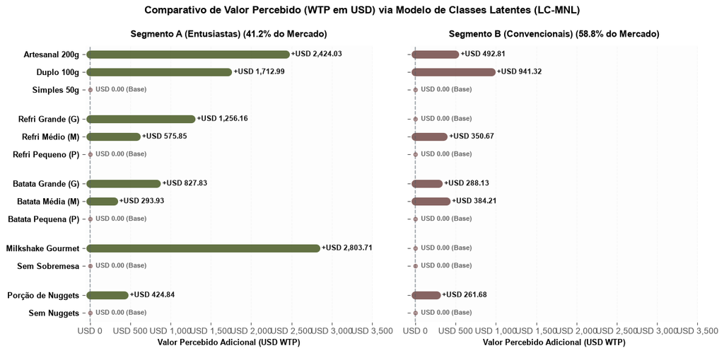

```python
# Visualização comparativa da Disposição a Pagar (WTP) entre segmentos
y_positions = []
y_labels = []
current_y = 0
unique_attrs = list(attribute_structure.keys())[::-1]

for attr in unique_attrs:
    sub_df = df_seg_summary[(df_seg_summary['Segmento'] == "Segmento A (Entusiastas)") & (df_seg_summary['Atributo'] == attr)]
    for _, row in sub_df.iterrows():
        y_positions.append(current_y)
        clean_lbl = row['Nível'].replace(' (Base)', '')
        y_labels.append((current_y, row['Nível'], clean_lbl))
        current_y += 1.0
    current_y += 0.65

fig, axes = plt.subplots(1, 2, figsize=(12.0, 5.8), sharey=True)
color_SegA = "#4E5F2A"
color_SegB = "#774F4C"
max_val_plot = df_seg_summary['WTP_USD'].max()
offset_text = max_val_plot * 0.025

for ax_idx, (seg_name, prop_pct, col) in enumerate([("Segmento A (Entusiastas)", pi_C0 * 100, color_SegA), ("Segmento B (Convencionais)", pi_C1 * 100, color_SegB)]):
    ax = axes[ax_idx]
    df_sub = df_seg_summary[df_seg_summary['Segmento'] == seg_name]

    for (y, full_lvl_name, _) in y_labels:
        wtp_val = df_sub[df_sub['Nível'] == full_lvl_name]['WTP_USD'].values[0]
        if wtp_val > 0:
            ax.hlines(y, 0, wtp_val, colors=col, linewidth=9.5, capstyle='round', alpha=0.88, zorder=2)
            ax.text(wtp_val + offset_text, y, f"+USD {wtp_val:,.2f}", ha='left', va='center', fontsize=8.5, weight='bold', color='#111111')
        else:
            ax.plot(0, y, 'o', color='#704241', markersize=4.5, alpha=0.5, zorder=3)
            ax.text(offset_text, y, f"USD 0.00 (Base)", ha='left', va='center', fontsize=8.2, weight='bold', color='#666666')

    ax.axvline(0, color='#4f5b66', linestyle='--', linewidth=1.1, alpha=0.6)
    ax.set_ylim(-0.5, max(y_positions) + 0.5)
    ax.set_title(f"{seg_name} ({prop_pct:.1f}% do Mercado)", fontsize=10.5, weight='bold', pad=10, color='black')
    ax.set_xlabel("Valor Percebido Adicional (USD WTP)", fontsize=9, weight='bold', color='black')
    ax.set_xlim(-60, max_val_plot * 1.25)
    ax.xaxis.set_major_formatter(plt.FuncFormatter(lambda val, loc: f"USD {int(val):,}"))
    ax.grid(visible=True, axis='x', linestyle='--', alpha=0.5)
    ax.grid(visible=False, axis='y')
    for spine in ['top', 'right', 'left']:
        ax.spines[spine].set_visible(False)

axes[0].set_yticks([y for y, _, _ in y_labels])
axes[0].set_yticklabels([lbl for _, _, lbl in y_labels], weight='bold', fontsize=9, color='black')

plt.suptitle("Comparativo de Valor Percebido (WTP em USD) via Modelo de Classes Latentes (LC-MNL)", fontsize=12, weight='bold', y=0.99, color='black')
plt.tight_layout()
plt.show()
```

- **Estrelas:** Alto market share simultâneo e alto lucro unitário.
- **Iscas de Volume:** Alto market share simultâneo com margem moderada.
- **Nicho Premium:** Baixo market share simultâneo com margem unitária elevada.
- **Sub-otimizados:** Baixo market share e baixa margem unitária.

```
=== Medianas de Referência da Prateleira ===
Mediana Share Segmento A: 0.153%
Mediana Share Segmento B: 0.009%
Mediana do Lucro Unitário: USD 1,152.00

=== TOP 5 COMBOS ESTRELAS - SEGMENTO A (ENTUSIASTAS) ===
```

|  | Hamburguer | Refrigerante | Batata | Sobremesa | Nuggets | price | cost | Lucro_Unitario_USD | Share_SegA_% | Quadrante_SegA |
| --- | --- | --- | --- | --- | --- | --- | --- | --- | --- | --- |
| 230 | Duplo 100g | Refri Grande (G) | Batata Grande (G) | Sem Sobremesa | Porção de Nuggets | USD 3,799.00 | USD 2,620.00 | USD 1,179.00 | 0.91% | Estrelas (Alto Share, Alto Lucro Un.) |
| 237 | Duplo 100g | Refri Grande (G) | Batata Grande (G) | Milkshake Gourmet | Porção de Nuggets | USD 6,916.00 | USD 5,320.00 | USD 1,596.00 | 0.58% | Estrelas (Alto Share, Alto Lucro Un.) |
| 231 | Duplo 100g | Refri Grande (G) | Batata Grande (G) | Sem Sobremesa | Porção de Nuggets | USD 4,192.00 | USD 2,620.00 | USD 1,572.00 | 0.52% | Estrelas (Alto Share, Alto Lucro Un.) |
| 326 | Artesanal 200g | Refri Grande (G) | Batata Grande (G) | Sem Sobremesa | Porção de Nuggets | USD 4,959.00 | USD 3,420.00 | USD 1,539.00 | 0.48% | Estrelas (Alto Share, Alto Lucro Un.) |
| 183 | Duplo 100g | Refri Médio (M) | Batata Grande (G) | Sem Sobremesa | Porção de Nuggets | USD 3,632.00 | USD 2,270.00 | USD 1,362.00 | 0.43% | Estrelas (Alto Share, Alto Lucro Un.) |

```
=== TOP 5 COMBOS ESTRELAS - SEGMENTO B (CONVENCIONAIS) ===
```

|  | Hamburguer | Refrigerante | Batata | Sobremesa | Nuggets | price | cost | Lucro_Unitario_USD | Share_SegB_% | Quadrante_SegB |
| --- | --- | --- | --- | --- | --- | --- | --- | --- | --- | --- |
| 167 | Duplo 100g | Refri Médio (M) | Batata Média (M) | Sem Sobremesa | Porção de Nuggets | USD 3,472.00 | USD 2,170.00 | USD 1,302.00 | 0.69% | Estrelas (Alto Share, Alto Lucro Un.) |
| 163 | Duplo 100g | Refri Médio (M) | Batata Média (M) | Sem Sobremesa | Sem Nuggets | USD 3,280.00 | USD 2,050.00 | USD 1,230.00 | 0.63% | Estrelas (Alto Share, Alto Lucro Un.) |
| 119 | Duplo 100g | Refri Pequeno (P) | Batata Média (M) | Sem Sobremesa | Porção de Nuggets | USD 3,312.00 | USD 2,070.00 | USD 1,242.00 | 0.54% | Estrelas (Alto Share, Alto Lucro Un.) |
| 151 | Duplo 100g | Refri Médio (M) | Batata Pequena (P) | Sem Sobremesa | Porção de Nuggets | USD 3,312.00 | USD 2,070.00 | USD 1,242.00 | 0.52% | Estrelas (Alto Share, Alto Lucro Un.) |
| 183 | Duplo 100g | Refri Médio (M) | Batata Grande (G) | Sem Sobremesa | Porção de Nuggets | USD 3,632.00 | USD 2,270.00 | USD 1,362.00 | 0.50% | Estrelas (Alto Share, Alto Lucro Un.) |

[figure not shown]

```python
# 1. Geração do catálogo completo de 108 produtos e margens
attributes_catalog = {
    'Hamburguer': {'levels': ['Simples 50g', 'Duplo 100g', 'Artesanal 200g'], 'costs': {'Simples 50g': 800, 'Duplo 100g': 1400, 'Artesanal 200g': 2200}},
    'Refrigerante': {'levels': ['Refri Pequeno (P)', 'Refri Médio (M)', 'Refri Grande (G)'], 'costs': {'Refri Pequeno (P)': 150, 'Refri Médio (M)': 250, 'Refri Grande (G)': 600}},
    'Batata': {'levels': ['Batata Pequena (P)', 'Batata Média (M)', 'Batata Grande (G)'], 'costs': {'Batata Pequena (P)': 300, 'Batata Média (M)': 400, 'Batata Grande (G)': 500}},
    'Sobremesa': {'levels': ['Sem Sobremesa', 'Milkshake Gourmet'], 'costs': {'Sem Sobremesa': 0, 'Milkshake Gourmet': 2700}},
    'Nuggets': {'levels': ['Sem Nuggets', 'Porção de Nuggets'], 'costs': {'Sem Nuggets': 0, 'Porção de Nuggets': 120}}
}
margin_levels = [0.15, 0.30, 0.45, 0.60]

cat_names = list(attributes_catalog.keys())
cat_levels = [attributes_catalog[a]['levels'] for a in cat_names]

all_catalog_rows = []
for combo in itertools.product(*cat_levels):
    p_dict = dict(zip(cat_names, combo))

    # Aplicação das 3 restrições técnicas
    if p_dict['Sobremesa'] == 'Milkshake Gourmet' and (p_dict['Refrigerante'] == 'Refri Pequeno (P)' and p_dict['Hamburguer'] == 'Simples 50g'):
        continue
    if p_dict['Hamburguer'] == 'Artesanal 200g' and p_dict['Refrigerante'] == 'Refri Pequeno (P)':
        continue
    if p_dict['Hamburguer'] == 'Simples 50g' and p_dict['Refrigerante'] == 'Refri Grande (G)' and p_dict['Sobremesa'] == 'Sem Sobremesa':
        continue

    cost = sum(attributes_catalog[a]['costs'][p_dict[a]] for a in cat_names)
    for m in margin_levels:
        row = p_dict.copy()
        row['cost'] = cost
        row['margin'] = m
        row['price'] = round(cost * (1 + m), 2)
        row['price_k'] = row['price'] / 1000.0
        all_catalog_rows.append(row)

df_all_108 = pd.DataFrame(all_catalog_rows)

# Matriz Dummy dos 108 combos
df_108_dummies = pd.get_dummies(
    df_all_108,
    columns=['Hamburguer', 'Refrigerante', 'Batata', 'Sobremesa', 'Nuggets'],
    dtype=float
).rename(columns=clean_cols)

for c in feature_cols:
    if c not in df_108_dummies.columns and c != 'price_k':
        df_108_dummies[c] = 0.0

# 2. Simulação de Market Share Simultâneo via Softmax com Opt-Out
def simulate_segmented_shares(df_catalog, p_A, p_B):
    beta_vec_A = np.array([p_A[c] if c != 'is_none' else 0.0 for c in feature_cols])
    beta_vec_B = np.array([p_B[c] if c != 'is_none' else 0.0 for c in feature_cols])
    v_none_A = p_A['is_none']
    v_none_B = p_B['is_none']

    X_mat = df_108_dummies[feature_cols].copy()
    X_mat['price_k'] = df_catalog['price_k'].values
    X_mat['is_none'] = 0.0
    X_arr = X_mat.values

    V_A = X_arr @ beta_vec_A
    V_B = X_arr @ beta_vec_B

    exp_V_A = np.exp(V_A - np.max(np.append(V_A, v_none_A)))
    exp_none_A = np.exp(v_none_A - np.max(np.append(V_A, v_none_A)))
    P_segA = exp_V_A / (np.sum(exp_V_A) + exp_none_A)

    exp_V_B = np.exp(V_B - np.max(np.append(V_B, v_none_B)))
    exp_none_B = np.exp(v_none_B - np.max(np.append(V_B, v_none_B)))
    P_segB = exp_V_B / (np.sum(exp_V_B) + exp_none_B)

    overall_shares = pi_C0 * P_segA + pi_C1 * P_segB

    df_res = df_catalog.copy()
    df_res['Share_Geral_%'] = overall_shares * 100.0
    df_res['Share_SegA_%'] = P_segA * 100.0
    df_res['Share_SegB_%'] = P_segB * 100.0
    df_res['Lucro_Unitario_USD'] = df_res['price'] - df_res['cost']

    med_sh_A = df_res['Share_SegA_%'].median()
    med_sh_B = df_res['Share_SegB_%'].median()
    med_unit_profit = df_res['Lucro_Unitario_USD'].median()

    def classify_SegA(row):
        if row['Share_SegA_%'] >= med_sh_A and row['Lucro_Unitario_USD'] >= med_unit_profit:
            return 'Estrelas (Alto Share, Alto Lucro Un.)'
        elif row['Share_SegA_%'] >= med_sh_A and row['Lucro_Unitario_USD'] < med_unit_profit:
            return 'Iscas de Volume (Alto Share, Lucro Un. Moderado)'
        elif row['Share_SegA_%'] < med_sh_A and row['Lucro_Unitario_USD'] >= med_unit_profit:
            return 'Nicho Premium (Baixo Share, Alto Lucro Un.)'
        else:
            return 'Sub-otimizados (Baixo Share, Baixo Lucro Un.)'

    df_res['Quadrante_SegA'] = df_res.apply(classify_SegA, axis=1)

    def classify_SegB(row):
        if row['Share_SegB_%'] >= med_sh_B and row['Lucro_Unitario_USD'] >= med_unit_profit:
            return 'Estrelas (Alto Share, Alto Lucro Un.)'
        elif row['Share_SegB_%'] >= med_sh_B and row['Lucro_Unitario_USD'] < med_unit_profit:
            return 'Iscas de Volume (Alto Share, Lucro Un. Moderado)'
        elif row['Share_SegB_%'] < med_sh_B and row['Lucro_Unitario_USD'] >= med_unit_profit:
            return 'Nicho Premium (Baixo Share, Alto Lucro Un.)'
        else:
            return 'Sub-otimizados (Baixo Share, Baixo Lucro Un.)'

    df_res['Quadrante_SegB'] = df_res.apply(classify_SegB, axis=1)
    return df_res, med_sh_A, med_sh_B, med_unit_profit

df_res_unit, med_sh_A, med_sh_B, med_unit_profit = simulate_segmented_shares(df_all_108, betas_dict_SegA, betas_dict_SegB)

print("=== Medianas de Referência da Prateleira ===")
print(f"Mediana Share Segmento A: {med_sh_A:.3f}%")
print(f"Mediana Share Segmento B: {med_sh_B:.3f}%")
print(f"Mediana do Lucro Unitário: USD {med_unit_profit:,.2f}\n")

print("=== TOP 5 COMBOS ESTRELAS - SEGMENTO A (ENTUSIASTAS) ===")
top_segA = df_res_unit[df_res_unit['Quadrante_SegA'] == 'Estrelas (Alto Share, Alto Lucro Un.)'].sort_values(by='Share_SegA_%', ascending=False).head(5)
display(top_segA[['Hamburguer', 'Refrigerante', 'Batata', 'Sobremesa', 'Nuggets', 'price', 'cost', 'Lucro_Unitario_USD', 'Share_SegA_%', 'Quadrante_SegA']].style.format({
    'price': 'USD {:,.2f}',
    'cost': 'USD {:,.2f}',
    'Lucro_Unitario_USD': 'USD {:,.2f}',
    'Share_SegA_%': '{:.2f}%'
}))

print("=== TOP 5 COMBOS ESTRELAS - SEGMENTO B (CONVENCIONAIS) ===")
top_segB = df_res_unit[df_res_unit['Quadrante_SegB'] == 'Estrelas (Alto Share, Alto Lucro Un.)'].sort_values(by='Share_SegB_%', ascending=False).head(5)
display(top_segB[['Hamburguer', 'Refrigerante', 'Batata', 'Sobremesa', 'Nuggets', 'price', 'cost', 'Lucro_Unitario_USD', 'Share_SegB_%', 'Quadrante_SegB']].style.format({
    'price': 'USD {:,.2f}',
    'cost': 'USD {:,.2f}',
    'Lucro_Unitario_USD': 'USD {:,.2f}',
    'Share_SegB_%': '{:.2f}%'
}))

# 3. Gráfico Executivo da Matriz Estratégica
fig, axes = plt.subplots(1, 2, figsize=(14, 6.2), sharey=True)

palette_autumn = {
    'Estrelas (Alto Share, Alto Lucro Un.)': '#4E5F2A',
    'Iscas de Volume (Alto Share, Lucro Un. Moderado)': '#d97736',
    'Nicho Premium (Baixo Share, Alto Lucro Un.)': '#6a4c6d',
    'Sub-otimizados (Baixo Share, Baixo Lucro Un.)': '#774F4C'
}

for ax_idx, (seg_col, seg_name, med_sh) in enumerate([('Share_SegA_%', 'Segmento A (Entusiastas)', med_sh_A), ('Share_SegB_%', 'Segmento B (Convencionais)', med_sh_B)]):
    ax = axes[ax_idx]
    quad_col = 'Quadrante_SegA' if seg_col == 'Share_SegA_%' else 'Quadrante_SegB'

    sns.scatterplot(
        data=df_res_unit,
        x=seg_col,
        y='Lucro_Unitario_USD',
        hue=quad_col,
        palette=palette_autumn,
        style=quad_col,
        s=95,
        alpha=0.88,
        ax=ax,
        legend=(ax_idx == 1)
    )

    ax.axvline(med_sh, color='#2c3e50', linestyle='--', linewidth=1.4, alpha=0.75)
    ax.axhline(med_unit_profit, color='#2c3e50', linestyle='--', linewidth=1.4, alpha=0.75)

    ax.set_title(f'Matriz de Portfólio: {seg_name}', fontsize=13, weight='bold', pad=12, color='black')
    ax.set_xlabel('Market Share Simultâneo no Segmento (%)', fontsize=12, weight='bold', color='black')
    if ax_idx == 0:
        ax.set_ylabel('Lucro Unitário por Combo (USD)', fontsize=12, weight='bold', color='black')

    ax.yaxis.set_major_formatter(plt.FuncFormatter(lambda val, loc: f"USD {int(val):,}"))
    ax.xaxis.set_major_formatter(plt.FuncFormatter(lambda val, loc: f"{val:.1f}%"))
    ax.tick_params(axis='both', labelsize=12)

    for spine in ['top', 'right']:
        ax.spines[spine].set_visible(False)

axes[1].legend(
    title="Região Estratégica",
    frameon=True,
    facecolor='white',
    edgecolor='#bdc3c7',
    fontsize=11.5,
    title_fontsize=12,
    loc='upper right'
)

plt.suptitle("Matriz Estratégica de Precificação e Portfólio (todas as 108 combinações)", fontsize=15, weight='bold', y=0.99, color='black')
plt.tight_layout()
plt.show()
```

## 7. Diagnóstico da Prateleira Atual da Loja (Histórico de Vendas PDV)

Importação do catálogo atual de 12 SKUs e consolidação do histórico mensal de vendas registradas no PDV. Identifica-se que:

- Produtos de entrada (SKUs 01 e 02) estão **subprecificados**, deixando margem na mesa.
- Produtos topo de linha (SKUs 07, 11 e 12) estão **sobreprecificados**, reprimindo demanda.
- O **SKU 06** apresenta distorção severa de precificação: vendido abaixo de combos inferiores (SKU 05), inflacionando volume mas canibalizando margem líquida.

```
=== Desempenho Histórico da Loja (Prateleira Pré-Otimização) ===
Volume Total Vendido: 34,038 unidades/mês
Faturamento Total: USD 152,115,462.00 /mês
Lucro Total Atual: USD 80,671,252.00 /mês
```

|  | SKU | Hamburguer | Refrigerante | Batata | Sobremesa | Nuggets | Preço_USD | Custo_USD | Vendas_Historicas_Un | Faturamento_Mensal_USD | Lucro_Total_Mensal_USD | Share_Mercado_% |
| --- | --- | --- | --- | --- | --- | --- | --- | --- | --- | --- | --- | --- |
| 0 | SKU 01 | Simples 50g | Refri Pequeno (P) | Batata Pequena (P) | Sem Sobremesa | Sem Nuggets | USD 2,599.00 | USD 1,250.00 | 6,712 | USD 17,444,488.00 | USD 9,054,488.00 | 13.90% |
| 1 | SKU 02 | Simples 50g | Refri Médio (M) | Batata Pequena (P) | Sem Sobremesa | Sem Nuggets | USD 3,199.00 | USD 1,350.00 | 5,240 | USD 16,762,760.00 | USD 9,688,760.00 | 10.85% |
| 2 | SKU 03 | Simples 50g | Refri Médio (M) | Batata Média (M) | Sem Sobremesa | Porção de Nuggets | USD 3,799.00 | USD 1,570.00 | 5,892 | USD 22,383,708.00 | USD 13,133,268.00 | 12.20% |
| 3 | SKU 04 | Duplo 100g | Refri Médio (M) | Batata Média (M) | Sem Sobremesa | Sem Nuggets | USD 4,999.00 | USD 2,050.00 | 4,051 | USD 20,250,949.00 | USD 11,946,399.00 | 8.39% |
| 4 | SKU 05 | Duplo 100g | Refri Médio (M) | Batata Média (M) | Sem Sobremesa | Porção de Nuggets | USD 5,399.00 | USD 2,170.00 | 3,874 | USD 20,915,726.00 | USD 12,509,146.00 | 8.02% |
| 5 | SKU 06 | Artesanal 200g | Refri Pequeno (P) | Batata Pequena (P) | Sem Sobremesa | Sem Nuggets | USD 4,599.00 | USD 2,650.00 | 3,618 | USD 16,639,182.00 | USD 7,051,482.00 | 7.49% |
| 6 | SKU 07 | Duplo 100g | Refri Grande (G) | Batata Grande (G) | Sem Sobremesa | Sem Nuggets | USD 6,999.00 | USD 2,500.00 | 782 | USD 5,473,218.00 | USD 3,518,218.00 | 1.62% |
| 7 | SKU 08 | Simples 50g | Refri Médio (M) | Batata Média (M) | Milkshake Gourmet | Sem Nuggets | USD 6,699.00 | USD 4,150.00 | 837 | USD 5,607,063.00 | USD 2,133,513.00 | 1.73% |
| 8 | SKU 09 | Duplo 100g | Refri Médio (M) | Batata Média (M) | Milkshake Gourmet | Sem Nuggets | USD 7,999.00 | USD 4,750.00 | 1,563 | USD 12,502,437.00 | USD 5,078,187.00 | 3.24% |
| 9 | SKU 10 | Duplo 100g | Refri Médio (M) | Batata Média (M) | Milkshake Gourmet | Porção de Nuggets | USD 8,799.00 | USD 4,870.00 | 878 | USD 7,725,522.00 | USD 3,449,662.00 | 1.82% |
| 10 | SKU 11 | Duplo 100g | Refri Grande (G) | Batata Grande (G) | Milkshake Gourmet | Sem Nuggets | USD 10,299.00 | USD 5,200.00 | 342 | USD 3,522,258.00 | USD 1,743,858.00 | 0.71% |
| 11 | SKU 12 | Artesanal 200g | Refri Grande (G) | Batata Grande (G) | Milkshake Gourmet | Porção de Nuggets | USD 11,599.00 | USD 6,120.00 | 249 | USD 2,888,151.00 | USD 1,364,271.00 | 0.52% |

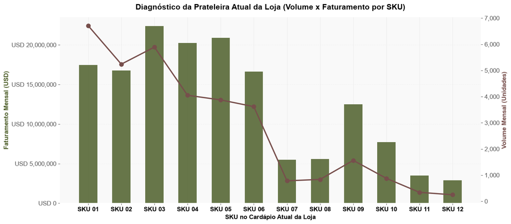

```python
# Diagnóstico da Prateleira Atual da Loja (Histórico Real de Vendas PDV)
df_shelf_preotm = pd.read_csv('portifolio preotm.csv')

# Preço em milhares para compatibilidade com o modelo
df_shelf_preotm['price_k'] = df_shelf_preotm['Preço_USD'] / 1000.0

df_shelf_dummies = pd.DataFrame()
df_shelf_dummies['price_k'] = df_shelf_preotm['price_k']

# Mapeamento com dummies do Conjoint (atributos camuflados)
feature_dummies_map = {
    'Hamburguer_Duplo_100g': df_shelf_preotm['Hamburguer'] == 'Duplo 100g',
    'Hamburguer_Artesanal_200g': df_shelf_preotm['Hamburguer'] == 'Artesanal 200g',
    'Refrigerante_Refri_Médio_M': df_shelf_preotm['Refrigerante'] == 'Refri Médio (M)',
    'Refrigerante_Refri_Grande_G': df_shelf_preotm['Refrigerante'] == 'Refri Grande (G)',
    'Batata_Batata_Média_M': df_shelf_preotm['Batata'] == 'Batata Média (M)',
    'Batata_Batata_Grande_G': df_shelf_preotm['Batata'] == 'Batata Grande (G)',
    'Sobremesa_Milkshake_Gourmet': df_shelf_preotm['Sobremesa'] == 'Milkshake Gourmet',
    'Nuggets_Porção_de_Nuggets': df_shelf_preotm['Nuggets'] == 'Porção de Nuggets'
}
for col, mask in feature_dummies_map.items():
    df_shelf_dummies[col] = mask.astype(float)
df_shelf_dummies['is_none'] = 0.0

# Funções de probabilidade do modelo LC-MNL
product_feature_cols = [c for c in feature_cols if c not in ['price_k', 'is_none']]
sku_dummy_matrix = df_shelf_dummies[product_feature_cols].values
v0_SegA = sku_dummy_matrix @ np.array([betas_dict_SegA[c] for c in product_feature_cols])
v0_SegB = sku_dummy_matrix @ np.array([betas_dict_SegB[c] for c in product_feature_cols])
b_price_A = betas_dict_SegA['price_k']
b_price_B = betas_dict_SegB['price_k']
v_none_A = betas_dict_SegA['is_none']
v_none_B = betas_dict_SegB['is_none']
w_A = pi_C0
w_B = pi_C1

prices_atual = df_shelf_preotm['Preço_USD'].values
costs = df_shelf_preotm['Custo_USD'].values
vol_atual = df_shelf_preotm['Vendas_Historicas_Un'].values

def compute_lc_mnl_probabilities(price_k_vec):
    V_A = v0_SegA + (price_k_vec * b_price_A)
    exp_A = np.exp(V_A - np.max(np.append(V_A, v_none_A)))
    exp_none_A = np.exp(v_none_A - np.max(np.append(V_A, v_none_A)))
    P_A = exp_A / (np.sum(exp_A) + exp_none_A)

    V_B = v0_SegB + (price_k_vec * b_price_B)
    exp_B = np.exp(V_B - np.max(np.append(V_B, v_none_B)))
    exp_none_B = np.exp(v_none_B - np.max(np.append(V_B, v_none_B)))
    P_B = exp_B / (np.sum(exp_B) + exp_none_B)

    return w_A * P_A + w_B * P_B

# Calibração do tráfego total da loja a partir do volume real de vendas do histórico PDV
P_purchase_base = np.sum(compute_lc_mnl_probabilities(prices_atual / 1000.0))
TOTAL_VISITANTES_ESTIMADO = np.sum(vol_atual) / P_purchase_base

# Consolidação financeira histórica da prateleira
rev_atual = vol_atual * prices_atual
profit_atual = vol_atual * (prices_atual - costs)

df_shelf_results = df_shelf_preotm.copy()
df_shelf_results['Faturamento_Mensal_USD'] = rev_atual
df_shelf_results['Lucro_Total_Mensal_USD'] = profit_atual
df_shelf_results['Share_Mercado_%'] = (vol_atual / TOTAL_VISITANTES_ESTIMADO) * 100.0

print("=== Desempenho Histórico da Loja (Prateleira Pré-Otimização) ===")
print(f"Volume Total Vendido: {df_shelf_results['Vendas_Historicas_Un'].sum():,} unidades/mês")
print(f"Faturamento Total: USD {df_shelf_results['Faturamento_Mensal_USD'].sum():,.2f} /mês")
print(f"Lucro Total Atual: USD {df_shelf_results['Lucro_Total_Mensal_USD'].sum():,.2f} /mês\n")

display(df_shelf_results[[
    'SKU', 'Hamburguer', 'Refrigerante', 'Batata', 'Sobremesa', 'Nuggets',
    'Preço_USD', 'Custo_USD', 'Vendas_Historicas_Un',
    'Faturamento_Mensal_USD', 'Lucro_Total_Mensal_USD', 'Share_Mercado_%'
]].style.format({
    'Preço_USD': 'USD {:,.2f}',
    'Custo_USD': 'USD {:,.2f}',
    'Vendas_Historicas_Un': '{:,}',
    'Faturamento_Mensal_USD': 'USD {:,.2f}',
    'Lucro_Total_Mensal_USD': 'USD {:,.2f}',
    'Share_Mercado_%': '{:.2f}%'
}))
# Gráfico de Vendas e Faturamento por SKU
plt.style.use('ggplot')
plt.rcParams.update({
    'font.family': 'sans-serif',
    'font.sans-serif': ['Arial', 'DejaVu Sans'],
    'axes.facecolor': '#f9f9f9',
    'figure.facecolor': 'white',
    'grid.color': '#ececec'
})

fig, ax1 = plt.subplots(figsize=(14, 6.2))

color_bar = '#4E5F2A'
color_line = '#774F4C'

x_pos = np.arange(len(df_shelf_results))
sku_labels = df_shelf_results['SKU']

bars = ax1.bar(x_pos, df_shelf_results['Faturamento_Mensal_USD'], color=color_bar, alpha=0.85, width=0.55, label='Faturamento Mensal (USD)')
ax1.set_ylabel('Faturamento Mensal (USD)', fontsize=12, weight='bold', color=color_bar)
ax1.set_xlabel('SKU no Cardápio Atual da Loja', fontsize=12, weight='bold', color='black')
ax1.yaxis.set_major_formatter(plt.FuncFormatter(lambda val, loc: f"USD {int(val):,}"))
ax1.set_xticks(x_pos)
ax1.set_xticklabels(sku_labels, fontsize=12, weight='bold', color='black')
ax1.tick_params(axis='both', labelsize=12)

ax2 = ax1.twinx()
ax2.plot(x_pos, df_shelf_results['Vendas_Historicas_Un'], color=color_line, marker='o', linewidth=2.5, markersize=8, label='Volume Vendido (Unidades)')
ax2.set_ylabel('Volume Mensal (Unidades)', fontsize=12, weight='bold', color=color_line)
ax2.yaxis.set_major_formatter(plt.FuncFormatter(lambda val, loc: f"{int(val):,}"))
ax2.tick_params(axis='y', labelsize=12)

ax1.grid(visible=True, axis='y', linestyle='--', alpha=0.5)
ax2.grid(visible=False)

for spine in ['top', 'right', 'left']:
    ax1.spines[spine].set_visible(False)
    ax2.spines[spine].set_visible(False)

plt.title("Diagnóstico da Prateleira Atual da Loja (Volume x Faturamento por SKU)", fontsize=15, weight='bold', pad=15, color='black')
plt.tight_layout()
plt.show()
```

## 8. Cálculo de Preço Ótimo por Demanda Agregada Multivariada (Solver L-BFGS-B)

Otimização simultânea dos preços dos 12 SKUs integrando a curva de demanda agregada não-linear do modelo Choice-Based Conjoint (LC-MNL). A função objetivo maximiza o lucro total da prateleira considerando a probabilidade de escolha conjunta entre segmentos, elasticidade cruzada, canibalização entre produtos e fuga para o *opt-out*, sob restrições operacionais de markup $[1.05\times, 3.00\times]$.

```python
# Cálculo de Preço Ótimo por Demanda Agregada Multivariada (LC-MNL)
# Maximiza o lucro total da prateleira considerando canibalização e opt-out
def loss_func(p_k_vec):
    D_sku = compute_lc_mnl_probabilities(p_k_vec)
    margins = (p_k_vec * 1000.0) - costs
    return -np.sum(margins * D_sku * TOTAL_VISITANTES_ESTIMADO)

bounds = [(c * 1.05 / 1000.0, c * 3.00 / 1000.0) for c in costs]
res = minimize(loss_func, x0=prices_atual / 1000.0, method='L-BFGS-B', bounds=bounds)
optimal_prices = res.x * 1000.0

P_sku_opt = compute_lc_mnl_probabilities(optimal_prices / 1000.0)
vol_opt = P_sku_opt * TOTAL_VISITANTES_ESTIMADO
profit_opt = (optimal_prices - costs) * vol_opt

tot_vol_atual = np.sum(vol_atual)
tot_vol_opt = np.sum(vol_opt)
tot_prof_atual = np.sum(profit_atual)
tot_prof_opt = np.sum(profit_opt)

df_comp = df_shelf_preotm.copy()
df_comp['Preço_Atual'] = prices_atual
df_comp['Preço_Otimizado'] = optimal_prices
df_comp['Vendas_Atual'] = np.round(vol_atual).astype(int)
df_comp['Vendas_Otimizado'] = np.round(vol_opt).astype(int)
df_comp['Share_Atual_%'] = (vol_atual / TOTAL_VISITANTES_ESTIMADO) * 100.0
df_comp['Share_Otimizado_%'] = P_sku_opt * 100.0
df_comp['Lucro_Atual_USD'] = profit_atual
df_comp['Lucro_Otimizado_USD'] = profit_opt

print("=== Resultados da Otimização Multivariada de Preços ===")
print(f"👥 Fluxo Total de Visitantes Estimado: {TOTAL_VISITANTES_ESTIMADO:,.0f} pessoas / mês")
print(f"🔹 Unidades Vendidas Atuais (Base):   {tot_vol_atual:,.0f} unidades / mês")
print(f"🔹 Unidades Vendidas Otimizadas:      {tot_vol_opt:,.0f} unidades / mês")
print(f"🔹 Lucro Total Atual:                 USD {tot_prof_atual:,.2f}")
print(f"🔹 Lucro Total Otimizado:             USD {tot_prof_opt:,.2f}")
print(f"💰 Crescimento no Lucro Líquido:      +{((tot_prof_opt - tot_prof_atual)/tot_prof_atual)*100:.1f}%\n")

display(df_comp[[
    'SKU', 'Hamburguer', 'Refrigerante', 'Batata', 'Sobremesa', 'Nuggets',
    'Preço_Atual', 'Preço_Otimizado', 'Vendas_Atual', 'Vendas_Otimizado',
    'Lucro_Atual_USD', 'Lucro_Otimizado_USD'
]].style.format({
    'Preço_Atual': 'USD {:,.2f}',
    'Preço_Otimizado': 'USD {:,.2f}',
    'Vendas_Atual': '{:,}',
    'Vendas_Otimizado': '{:,}',
    'Lucro_Atual_USD': 'USD {:,.2f}',
    'Lucro_Otimizado_USD': 'USD {:,.2f}'
}))
```

```
=== Resultados da Otimização Multivariada de Preços ===
👥 Fluxo Total de Visitantes Estimado: 48,280 pessoas / mês
🔹 Unidades Vendidas Atuais (Base):   34,038 unidades / mês
🔹 Unidades Vendidas Otimizadas:      32,654 unidades / mês
🔹 Lucro Total Atual:                 USD 80,671,252.00
🔹 Lucro Total Otimizado:             USD 94,406,643.30
💰 Crescimento no Lucro Líquido:      +17.0%
```

|  | SKU | Hamburguer | Refrigerante | Batata | Sobremesa | Nuggets | Preço_Atual | Preço_Otimizado | Vendas_Atual | Vendas_Otimizado | Lucro_Atual_USD | Lucro_Otimizado_USD |
| --- | --- | --- | --- | --- | --- | --- | --- | --- | --- | --- | --- | --- |
| 0 | SKU 01 | Simples 50g | Refri Pequeno (P) | Batata Pequena (P) | Sem Sobremesa | Sem Nuggets | USD 2,599.00 | USD 3,597.25 | 6,712 | 1,964 | USD 9,054,488.00 | USD 4,608,986.17 |
| 1 | SKU 02 | Simples 50g | Refri Médio (M) | Batata Pequena (P) | Sem Sobremesa | Sem Nuggets | USD 3,199.00 | USD 3,765.07 | 5,240 | 2,632 | USD 9,688,760.00 | USD 6,355,748.03 |
| 2 | SKU 03 | Simples 50g | Refri Médio (M) | Batata Média (M) | Sem Sobremesa | Porção de Nuggets | USD 3,799.00 | USD 4,021.53 | 5,892 | 4,497 | USD 13,133,268.00 | USD 11,023,569.03 |
| 3 | SKU 04 | Duplo 100g | Refri Médio (M) | Batata Média (M) | Sem Sobremesa | Sem Nuggets | USD 4,999.00 | USD 4,749.74 | 4,051 | 5,455 | USD 11,946,399.00 | USD 14,725,819.57 |
| 4 | SKU 05 | Duplo 100g | Refri Médio (M) | Batata Média (M) | Sem Sobremesa | Porção de Nuggets | USD 5,399.00 | USD 4,950.24 | 3,874 | 6,537 | USD 12,509,146.00 | USD 18,175,476.66 |
| 5 | SKU 06 | Artesanal 200g | Refri Pequeno (P) | Batata Pequena (P) | Sem Sobremesa | Sem Nuggets | USD 4,599.00 | USD 5,722.87 | 3,618 | 621 | USD 7,051,482.00 | USD 1,908,883.46 |
| 6 | SKU 07 | Duplo 100g | Refri Grande (G) | Batata Grande (G) | Sem Sobremesa | Sem Nuggets | USD 6,999.00 | USD 5,813.81 | 782 | 3,058 | USD 3,518,218.00 | USD 10,134,838.24 |
| 7 | SKU 08 | Simples 50g | Refri Médio (M) | Batata Média (M) | Milkshake Gourmet | Sem Nuggets | USD 6,699.00 | USD 7,618.00 | 837 | 167 | USD 2,133,513.00 | USD 577,762.34 |
| 8 | SKU 09 | Duplo 100g | Refri Médio (M) | Batata Média (M) | Milkshake Gourmet | Sem Nuggets | USD 7,999.00 | USD 8,228.27 | 1,563 | 807 | USD 5,078,187.00 | USD 2,807,124.20 |
| 9 | SKU 10 | Duplo 100g | Refri Médio (M) | Batata Média (M) | Milkshake Gourmet | Porção de Nuggets | USD 8,799.00 | USD 8,349.43 | 878 | 1,248 | USD 3,449,662.00 | USD 4,342,671.75 |
| 10 | SKU 11 | Duplo 100g | Refri Grande (G) | Batata Grande (G) | Milkshake Gourmet | Sem Nuggets | USD 10,299.00 | USD 8,682.70 | 342 | 2,399 | USD 1,743,858.00 | USD 8,355,358.87 |
| 11 | SKU 12 | Artesanal 200g | Refri Grande (G) | Batata Grande (G) | Milkshake Gourmet | Porção de Nuggets | USD 11,599.00 | USD 9,603.04 | 249 | 3,270 | USD 1,364,271.00 | USD 11,390,404.98 |

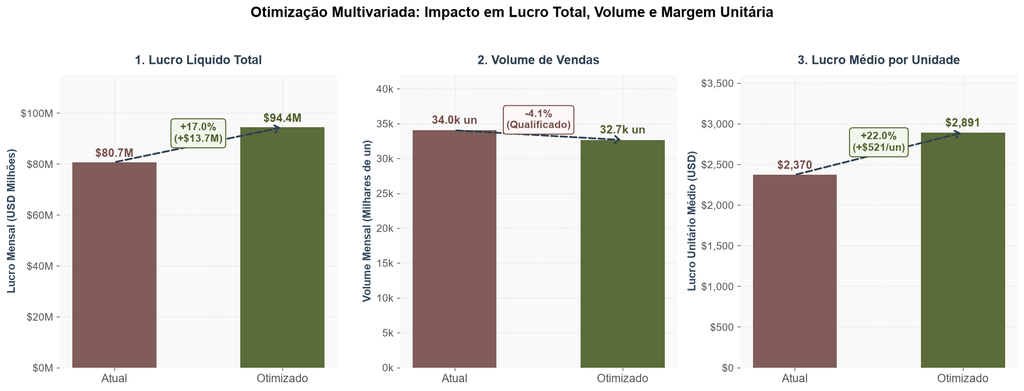

```python
# Gráfico Visual Executivo de Capa: Comparativo Antes vs Depois (Lucro, Volume e Margem Unitária)

# Métricas dinâmicas
diff_prof = tot_prof_opt - tot_prof_atual
growth_prof = (diff_prof / tot_prof_atual) * 100.0
diff_vol_pct = ((tot_vol_opt - tot_vol_atual) / tot_vol_atual) * 100.0
lucro_un_atual = tot_prof_atual / tot_vol_atual
lucro_un_opt = tot_prof_opt / tot_vol_opt
growth_un = ((lucro_un_opt - lucro_un_atual) / lucro_un_atual) * 100.0

c_atual = '#774F4C'
c_opt = '#4E5F2A'

fig, (ax1, ax2, ax3) = plt.subplots(1, 3, figsize=(16, 5.8), dpi=130)

# Painel 1: Lucro Líquido Total
ax1.bar(['Atual', 'Otimizado'], [tot_prof_atual/1e6, tot_prof_opt/1e6], color=[c_atual, c_opt], width=0.50, alpha=0.92, zorder=3)
ax1.text(0, (tot_prof_atual/1e6) + 1.2, f'${tot_prof_atual/1e6:.1f}M', ha='center', va='bottom', fontsize=12.5, weight='bold', color=c_atual)
ax1.text(1, (tot_prof_opt/1e6) + 1.2, f'${tot_prof_opt/1e6:.1f}M', ha='center', va='bottom', fontsize=12.5, weight='bold', color=c_opt)
ax1.annotate('', xy=(1, tot_prof_opt/1e6), xytext=(0, tot_prof_atual/1e6),
             arrowprops=dict(arrowstyle='->,head_width=0.4,head_length=0.5', color='#2c3e50', lw=2.0, linestyle='--'))
mid_y1 = (tot_prof_atual/1e6 + tot_prof_opt/1e6) / 2
ax1.text(0.5, mid_y1 + 4.5, f'+{growth_prof:.1f}%\n(+${diff_prof/1e6:.1f}M)', ha='center', va='center', fontsize=11.5, weight='bold', color='#4E5F2A',
         bbox=dict(boxstyle='round,pad=0.3', facecolor='#F0F7ED', edgecolor='#4E5F2A', linewidth=1.1))
ax1.set_title("1. Lucro Líquido Total", fontsize=14, weight='bold', pad=12, color='#2c3e50')
ax1.set_ylabel("Lucro Mensal (USD Milhões)", fontsize=12, weight='bold', color='#34495e')
ax1.set_ylim(0, 115)
ax1.yaxis.set_major_formatter(plt.FuncFormatter(lambda v, _: f"${int(v)}M"))

# Painel 2: Volume de Vendas
ax2.bar(['Atual', 'Otimizado'], [tot_vol_atual/1e3, tot_vol_opt/1e3], color=[c_atual, c_opt], width=0.50, alpha=0.92, zorder=3)
ax2.text(0, (tot_vol_atual/1e3) + 0.6, f'{tot_vol_atual/1e3:.1f}k un', ha='center', va='bottom', fontsize=12.5, weight='bold', color=c_atual)
ax2.text(1, (tot_vol_opt/1e3) + 0.6, f'{tot_vol_opt/1e3:.1f}k un', ha='center', va='bottom', fontsize=12.5, weight='bold', color=c_opt)
ax2.annotate('', xy=(1, tot_vol_opt/1e3), xytext=(0, tot_vol_atual/1e3),
             arrowprops=dict(arrowstyle='->,head_width=0.4,head_length=0.5', color='#2c3e50', lw=2.0, linestyle='--'))
mid_y2 = (tot_vol_atual/1e3 + tot_vol_opt/1e3) / 2
ax2.text(0.5, mid_y2 + 2.2, f'{diff_vol_pct:.1f}%\n(Qualificado)', ha='center', va='center', fontsize=11.5, weight='bold', color='#774F4C',
         bbox=dict(boxstyle='round,pad=0.3', facecolor='#FDF7F7', edgecolor='#774F4C', linewidth=1.1))
ax2.set_title("2. Volume de Vendas", fontsize=14, weight='bold', pad=12, color='#2c3e50')
ax2.set_ylabel("Volume Mensal (Milhares de un)", fontsize=12, weight='bold', color='#34495e')
ax2.set_ylim(0, 42)
ax2.yaxis.set_major_formatter(plt.FuncFormatter(lambda v, _: f"{int(v)}k"))

# Painel 3: Margem Unitária (Lucro por Unidade)
ax3.bar(['Atual', 'Otimizado'], [lucro_un_atual, lucro_un_opt], color=[c_atual, c_opt], width=0.50, alpha=0.92, zorder=3)
ax3.text(0, lucro_un_atual + 45, f'${lucro_un_atual:,.0f}', ha='center', va='bottom', fontsize=12.5, weight='bold', color=c_atual)
ax3.text(1, lucro_un_opt + 45, f'${lucro_un_opt:,.0f}', ha='center', va='bottom', fontsize=12.5, weight='bold', color=c_opt)
ax3.annotate('', xy=(1, lucro_un_opt), xytext=(0, lucro_un_atual),
             arrowprops=dict(arrowstyle='->,head_width=0.4,head_length=0.5', color='#2c3e50', lw=2.0, linestyle='--'))
mid_y3 = (lucro_un_atual + lucro_un_opt) / 2
ax3.text(0.5, mid_y3 + 140, f'+{growth_un:.1f}%\n(+${(lucro_un_opt-lucro_un_atual):.0f}/un)', ha='center', va='center', fontsize=11.5, weight='bold', color='#4E5F2A',
         bbox=dict(boxstyle='round,pad=0.3', facecolor='#F0F7ED', edgecolor='#4E5F2A', linewidth=1.1))
ax3.set_title("3. Lucro Médio por Unidade", fontsize=14, weight='bold', pad=12, color='#2c3e50')
ax3.set_ylabel("Lucro Unitário Médio (USD)", fontsize=12, weight='bold', color='#34495e')
ax3.set_ylim(0, 3600)
ax3.yaxis.set_major_formatter(plt.FuncFormatter(lambda v, _: f"${int(v):,}"))

# Formatação limpa (despine)
for ax in [ax1, ax2, ax3]:
    ax.tick_params(axis='x', labelsize=12.5)
    ax.tick_params(axis='y', labelsize=11.5)
    for spine in ['top', 'right', 'left', 'bottom']:
        ax.spines[spine].set_visible(False)
    ax.grid(True, axis='y', linestyle='--', alpha=0.35, color='#bdc3c7')

plt.suptitle("Otimização Multivariada: Impacto em Lucro Total, Volume e Margem Unitária", fontsize=16, weight='bold', y=1.04, color='black')
plt.tight_layout()
plt.show()
```

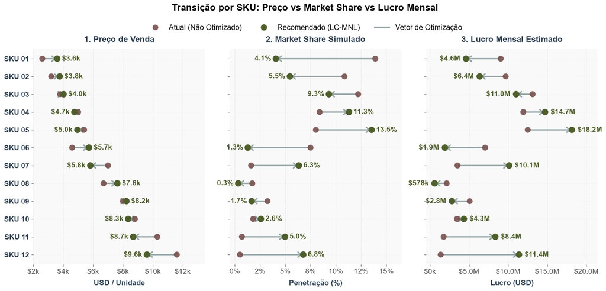

```python
# Visualização Dumbbell de transição (Preço vs Share vs Lucro) - Compacto & Alta Nitidez
df_plot = df_comp.iloc[::-1].reset_index(drop=True)
y_pos = np.arange(len(df_plot))
c_atual = '#774F4C'
c_opt = '#4E5F2A'

# Tamanho compacto para alta densidade visual e nitidez
fig, (ax1, ax2, ax3) = plt.subplots(1, 3, figsize=(15, 6.8), sharey=True, dpi=120)

# Painel 1: Preço
for i in range(len(df_plot)):
    p0, p1 = df_plot['Preço_Atual'].iloc[i], df_plot['Preço_Otimizado'].iloc[i]
    y = y_pos[i]
    ax1.annotate('', xy=(p1, y), xytext=(p0, y),
                 arrowprops=dict(arrowstyle='->,head_width=0.45,head_length=0.55', color='#95a5a6', lw=2.4))
    ax1.scatter(p0, y, color=c_atual, s=110, zorder=3, edgecolors='none', alpha=0.9)
    ax1.scatter(p1, y, color=c_opt, s=130, zorder=4, edgecolors='none')
    offset = 320 if p1 >= p0 else -320
    ha = 'left' if p1 >= p0 else 'right'
    ax1.text(p1 + offset, y, f"${p1/1000:.1f}k", va='center', ha=ha, fontsize=12.5, color=c_opt, weight='bold')

ax1.set_title("1. Preço de Venda", fontsize=14.5, weight='bold', pad=12, color='#2c3e50')
ax1.set_xlabel("USD / Unidade", fontsize=13, weight='bold', color='#34495e', labelpad=8)
ax1.set_yticks(y_pos)
ax1.set_yticklabels(df_plot['SKU'], fontsize=13, weight='bold', color='#2c3e50')
ax1.xaxis.set_major_formatter(plt.FuncFormatter(lambda v, _: f"${int(v/1000)}k"))
ax1.set_xlim(2000, 13500)

# Painel 2: Market Share
for i in range(len(df_plot)):
    s0, s1 = df_plot['Share_Atual_%'].iloc[i], df_plot['Share_Otimizado_%'].iloc[i]
    y = y_pos[i]
    ax2.annotate('', xy=(s1, y), xytext=(s0, y),
                 arrowprops=dict(arrowstyle='->,head_width=0.45,head_length=0.55', color='#95a5a6', lw=2.4))
    ax2.scatter(s0, y, color=c_atual, s=110, zorder=3, edgecolors='none', alpha=0.9)
    ax2.scatter(s1, y, color=c_opt, s=130, zorder=4, edgecolors='none')
    offset = 0.45 if s1 >= s0 else -0.45
    ha = 'left' if s1 >= s0 else 'right'
    ax2.text(s1 + offset, y, f"{s1:.1f}%", va='center', ha=ha, fontsize=12.5, color=c_opt, weight='bold')

ax2.set_title("2. Market Share Simulado", fontsize=14.5, weight='bold', pad=12, color='#2c3e50')
ax2.set_xlabel("Penetração (%)", fontsize=13, weight='bold', color='#34495e', labelpad=8)
ax2.xaxis.set_major_formatter(plt.FuncFormatter(lambda v, _: f"{v:.0f}%"))
ax2.set_xlim(-0.5, 16.5)

# Painel 3: Lucro Mensal
lucro_k_atual = df_plot['Lucro_Atual_USD'] / 1e3
lucro_k_opt = df_plot['Lucro_Otimizado_USD'] / 1e3
for i in range(len(df_plot)):
    l0, l1 = lucro_k_atual.iloc[i], lucro_k_opt.iloc[i]
    y = y_pos[i]
    ax3.annotate('', xy=(l1, y), xytext=(l0, y),
                 arrowprops=dict(arrowstyle='->,head_width=0.45,head_length=0.55', color='#95a5a6', lw=2.4))
    ax3.scatter(l0, y, color=c_atual, s=110, zorder=3, edgecolors='none', alpha=0.9)
    ax3.scatter(l1, y, color=c_opt, s=130, zorder=4, edgecolors='none')
    offset = max(lucro_k_opt.max(), lucro_k_atual.max()) * 0.04
    offset_val = offset if l1 >= l0 else -offset
    ha = 'left' if l1 >= l0 else 'right'
    val_str = f"${l1/1e3:.1f}M" if l1 >= 1000 else f"${l1:.0f}k"
    ax3.text(l1 + offset_val, y, val_str, va='center', ha=ha, fontsize=12.5, color=c_opt, weight='bold')

ax3.set_title("3. Lucro Mensal Estimado", fontsize=14.5, weight='bold', pad=12, color='#2c3e50')
ax3.set_xlabel("Lucro (USD)", fontsize=13, weight='bold', color='#34495e', labelpad=8)
ax3.xaxis.set_major_formatter(plt.FuncFormatter(lambda v, _: f"${v/1e3:.1f}M" if v >= 1000 else f"${int(v)}k"))
ax3.set_xlim(-500, 21500)

# Remoção de quadros/bordas (despine) e grade sutil
for ax in [ax1, ax2, ax3]:
    ax.tick_params(axis='both', labelsize=12.5)
    for spine in ['top', 'right', 'left', 'bottom']:
        ax.spines[spine].set_visible(False)
    ax.grid(True, axis='x', linestyle='--', alpha=0.35, color='#bdc3c7')
    ax.grid(True, axis='y', linestyle=':', alpha=0.20, color='#bdc3c7')

legend_elements = [
    plt.Line2D([0], [0], marker='o', color='w', label='Atual (Não Otimizado)', markerfacecolor=c_atual, markersize=11, alpha=0.9),
    plt.Line2D([0], [0], marker='o', color='w', label='Recomendado (LC-MNL)', markerfacecolor=c_opt, markersize=12),
    plt.Line2D([0], [0], color='#95a5a6', linestyle='-', lw=2.4, label='Vetor de Otimização')
]
fig.legend(handles=legend_elements, loc='upper center', bbox_to_anchor=(0.5, 0.99), ncol=3, frameon=False, fontsize=13)

plt.suptitle("Transição por SKU: Preço vs Market Share vs Lucro Mensal", fontsize=16, weight='bold', y=1.04, color='black')
plt.tight_layout()
plt.show()
```

## 9. Otimização Combinatória de Assortment (Purga de Catálogo)

Varredura exaustiva de combinações para avaliar a retenção de lucro ao reduzir o catálogo de $K=11$ até $K=6$ SKUs.

```python
import itertools

catalog_skus = df_comp['SKU'].tolist()
n_total = len(catalog_skus)
lucro_teto_12 = tot_prof_opt

def optimize_sub_shelf(indices):
    sub_costs = costs[indices]
    sub_v0_A = v0_SegA[indices]
    sub_v0_B = v0_SegB[indices]

    def sub_loss(p_k):
        v_A = sub_v0_A + (p_k * b_price_A)
        exp_A = np.exp(v_A - np.max(np.append(v_A, v_none_A)))
        exp_none_A = np.exp(v_none_A - np.max(np.append(v_A, v_none_A)))
        p_A = exp_A / (np.sum(exp_A) + exp_none_A)

        v_B = sub_v0_B + (p_k * b_price_B)
        exp_B = np.exp(v_B - np.max(np.append(v_B, v_none_B)))
        exp_none_B = np.exp(v_none_B - np.max(np.append(v_B, v_none_B)))
        p_B = exp_B / (np.sum(exp_B) + exp_none_B)

        demands = (w_A * p_A) + (w_B * p_B)
        margins = (p_k * 1000.0) - sub_costs
        return -np.sum(margins * demands * TOTAL_VISITANTES_ESTIMADO)

    init_p = optimal_prices[indices] / 1000.0
    bounds = [(c * 1.05 / 1000.0, c * 3.00 / 1000.0) for c in sub_costs]
    res = minimize(sub_loss, x0=init_p, method='L-BFGS-B', bounds=bounds)
    return -res.fun, res.x * 1000.0

target_k_list = [11, 10, 9, 8, 7, 6]
results_pruning = []

for k in target_k_list:
    combos = list(itertools.combinations(range(n_total), k))
    best_profit = -np.inf
    best_indices = None
    best_prices = None

    for combo_idx in combos:
        prof, p_vec = optimize_sub_shelf(list(combo_idx))
        if prof > best_profit:
            best_profit = prof
            best_indices = combo_idx
            best_prices = p_vec

    kept_skus = [catalog_skus[i] for i in best_indices]
    purged_skus = [s for s in catalog_skus if s not in kept_skus]
    results_pruning.append({
        'SKUs_Ativos': k,
        'Lucro_Total_USD': best_profit,
        'Retencao_Lucro_%': (best_profit / lucro_teto_12) * 100.0,
        'SKUs_Mantidos': ", ".join(kept_skus),
        'SKUs_Eliminados': ", ".join(purged_skus) if purged_skus else "Nenhum (Cardápio Cheio)"
    })

df_pruning = pd.DataFrame(results_pruning)

print("=== Resultado da Otimização Combinatória de Assortment ===")
display(df_pruning[['SKUs_Ativos', 'Retencao_Lucro_%', 'Lucro_Total_USD', 'SKUs_Eliminados']].style.format({
    'Retencao_Lucro_%': '{:.2f}%',
    'Lucro_Total_USD': 'USD {:,.2f}'
}))
```

```
=== Resultado da Otimização Combinatória de Assortment ===
```

|  | SKUs_Ativos | Retencao_Lucro_% | Lucro_Total_USD | SKUs_Eliminados |
| --- | --- | --- | --- | --- |
| 0 | 11 | 99.88% | USD 94,289,691.68 | SKU 08 |
| 1 | 10 | 99.37% | USD 93,815,990.75 | SKU 06, SKU 08 |
| 2 | 9 | 98.74% | USD 93,214,979.83 | SKU 06, SKU 08, SKU 09 |
| 3 | 8 | 97.67% | USD 92,202,579.91 | SKU 06, SKU 08, SKU 09, SKU 10 |
| 4 | 7 | 95.95% | USD 90,581,989.11 | SKU 01, SKU 06, SKU 08, SKU 09, SKU 10 |
| 5 | 6 | 93.49% | USD 88,258,003.60 | SKU 01, SKU 06, SKU 08, SKU 09, SKU 10, SKU 11 |

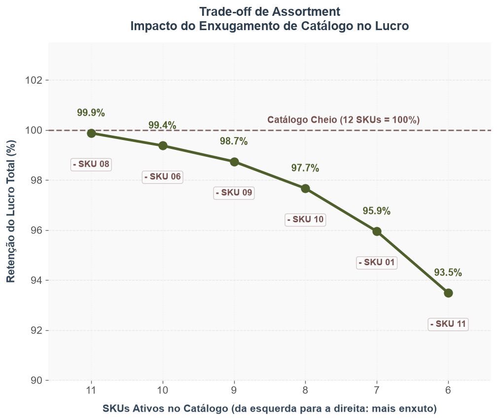

```python
# Curva de Trade-off com Eixo X Invertido (Storytelling de Enxugamento de Catálogo)
fig, ax1 = plt.subplots(figsize=(8.5, 7.2), dpi=120)
x_k = df_pruning['SKUs_Ativos']
y_ret = df_pruning['Retencao_Lucro_%']

# Extrai o SKU eliminado especificamente em cada etapa
marginal_purged = []
prev_elim = set()
for s_elim in df_pruning['SKUs_Eliminados']:
    current_elim = set(s_elim.split(', '))
    diff = current_elim - prev_elim
    marginal_purged.append('- ' + ', '.join(sorted(diff)))
    prev_elim = current_elim

# Linha de Trade-off
ax1.plot(x_k, y_ret, marker='o', color='#4E5F2A', linewidth=3.2, markersize=10, zorder=4, label='Retenção de Lucro (%)')

# Anotações: Lucro Acima + Badge do SKU Eliminado Abaixo
for k_val, r_val, rem_sku in zip(x_k, y_ret, marginal_purged):
    ax1.text(k_val, r_val + 0.6, f"{r_val:.1f}%", ha='center', va='bottom', fontsize=12, weight='bold', color='#4E5F2A')
    ax1.text(k_val, r_val - 1.1, f"{rem_sku}", ha='center', va='top', fontsize=10.5, weight='bold', color='#774F4C',
             bbox=dict(boxstyle='round,pad=0.25', facecolor='#fbfbfb', edgecolor='#d0c4c4', linewidth=0.8))

# Linha de Benchmark (100% de Lucro com Catálogo Cheio)
ax1.axhline(100.0, color='#774F4C', linestyle='--', linewidth=1.8, alpha=0.8, zorder=2)
# Como o eixo está invertido, o texto de 100% fica à esquerda (em X = 11.4)
ax1.text(6.4, 100.2, "Catálogo Cheio (12 SKUs = 100%)", ha='right', va='bottom', fontsize=11.5, weight='bold', color='#774F4C')

ax1.set_title("Trade-off de Assortment\nImpacto do Enxugamento de Catálogo no Lucro", fontsize=15, weight='bold', pad=15, color='#2c3e50')
ax1.set_xlabel("SKUs Ativos no Catálogo (da esquerda para a direita: mais enxuto)", fontsize=12.5, weight='bold', color='#34495e', labelpad=10)
ax1.set_ylabel("Retenção do Lucro Total (%)", fontsize=13, weight='bold', color='#34495e', labelpad=10)

ax1.set_xticks(df_pruning['SKUs_Ativos'])
# Inverte o eixo X: vai de 11.6 na esquerda até 5.4 na direita
ax1.set_xlim(11.6, 5.4)
ax1.set_ylim(min(y_ret) - 3.5, 103.5)
ax1.tick_params(axis='both', labelsize=12.5)

# Remoção de bordas (despine) e grid sutil
for spine in ['top', 'right', 'left', 'bottom']:
    ax1.spines[spine].set_visible(False)

ax1.grid(True, axis='y', linestyle='--', alpha=0.35, color='#bdc3c7')
ax1.grid(True, axis='x', linestyle=':', alpha=0.20, color='#bdc3c7')

plt.tight_layout()
plt.show()
```